# Part I - (Dataset Exploration Ford GoBike System Data)

## Introduction

> Introduce the dataset In this project, we will concentrate on visualizing the Ford GoBike System data set that includes information about individual rides made in a bike-sharing system covering the greater San Francisco Bay area.

Features included the dataset are:

- Trip Duration (seconds)
- Start Time and Date
- End Time and Date
- Start Station ID
- Start Station Name
- Start Station Latitude
- Start Station Longitude
- End Station ID
- End Station Name
- End Station Latitude
- End Station Longitude
- Bike ID
- User Type (Subscriber or Customer – “Subscriber” = Member or “Customer” = Casual)
- Member Year of Birth
- Member Gender

## Preliminary Wrangling

```python
# import all packages and set plots to be embedded inline
import numpy as np
import pandas as pd
import matplotlib.pyplot as plt
import seaborn as sb

%matplotlib inline
```

> Load in your dataset and describe its properties through the questions below. in this section i will assessing data visually and programatically.

```python
# load in the dataset into a pandas dataframe, print statistics
ford = pd.read_csv('201902-fordgobike-tripdata.csv')
ford.head()
```

|  | duration_sec | start_time | end_time | start_station_id | start_station_name | start_station_latitude | start_station_longitude | end_station_id | end_station_name | end_station_latitude | end_station_longitude | bike_id | user_type | member_birth_year | member_gender | bike_share_for_all_trip |
| --- | --- | --- | --- | --- | --- | --- | --- | --- | --- | --- | --- | --- | --- | --- | --- | --- |
| 0 | 52185 | 2019-02-28 17:32:10.1450 | 2019-03-01 08:01:55.9750 | 21.0 | Montgomery St BART Station (Market St at 2nd St) | 37.789625 | -122.400811 | 13.0 | Commercial St at Montgomery St | 37.794231 | -122.402923 | 4902 | Customer | 1984.0 | Male | No |
| 1 | 42521 | 2019-02-28 18:53:21.7890 | 2019-03-01 06:42:03.0560 | 23.0 | The Embarcadero at Steuart St | 37.791464 | -122.391034 | 81.0 | Berry St at 4th St | 37.775880 | -122.393170 | 2535 | Customer | NaN | NaN | No |
| 2 | 61854 | 2019-02-28 12:13:13.2180 | 2019-03-01 05:24:08.1460 | 86.0 | Market St at Dolores St | 37.769305 | -122.426826 | 3.0 | Powell St BART Station (Market St at 4th St) | 37.786375 | -122.404904 | 5905 | Customer | 1972.0 | Male | No |
| 3 | 36490 | 2019-02-28 17:54:26.0100 | 2019-03-01 04:02:36.8420 | 375.0 | Grove St at Masonic Ave | 37.774836 | -122.446546 | 70.0 | Central Ave at Fell St | 37.773311 | -122.444293 | 6638 | Subscriber | 1989.0 | Other | No |
| 4 | 1585 | 2019-02-28 23:54:18.5490 | 2019-03-01 00:20:44.0740 | 7.0 | Frank H Ogawa Plaza | 37.804562 | -122.271738 | 222.0 | 10th Ave at E 15th St | 37.792714 | -122.248780 | 4898 | Subscriber | 1974.0 | Male | Yes |

## Assessing Data

### Visual Assessment

```python
ford
```

|  | duration_sec | start_time | end_time | start_station_id | start_station_name | start_station_latitude | start_station_longitude | end_station_id | end_station_name | end_station_latitude | end_station_longitude | bike_id | user_type | member_birth_year | member_gender | bike_share_for_all_trip |
| --- | --- | --- | --- | --- | --- | --- | --- | --- | --- | --- | --- | --- | --- | --- | --- | --- |
| 0 | 52185 | 2019-02-28 17:32:10.1450 | 2019-03-01 08:01:55.9750 | 21.0 | Montgomery St BART Station (Market St at 2nd St) | 37.789625 | -122.400811 | 13.0 | Commercial St at Montgomery St | 37.794231 | -122.402923 | 4902 | Customer | 1984.0 | Male | No |
| 1 | 42521 | 2019-02-28 18:53:21.7890 | 2019-03-01 06:42:03.0560 | 23.0 | The Embarcadero at Steuart St | 37.791464 | -122.391034 | 81.0 | Berry St at 4th St | 37.775880 | -122.393170 | 2535 | Customer | NaN | NaN | No |
| 2 | 61854 | 2019-02-28 12:13:13.2180 | 2019-03-01 05:24:08.1460 | 86.0 | Market St at Dolores St | 37.769305 | -122.426826 | 3.0 | Powell St BART Station (Market St at 4th St) | 37.786375 | -122.404904 | 5905 | Customer | 1972.0 | Male | No |
| 3 | 36490 | 2019-02-28 17:54:26.0100 | 2019-03-01 04:02:36.8420 | 375.0 | Grove St at Masonic Ave | 37.774836 | -122.446546 | 70.0 | Central Ave at Fell St | 37.773311 | -122.444293 | 6638 | Subscriber | 1989.0 | Other | No |
| 4 | 1585 | 2019-02-28 23:54:18.5490 | 2019-03-01 00:20:44.0740 | 7.0 | Frank H Ogawa Plaza | 37.804562 | -122.271738 | 222.0 | 10th Ave at E 15th St | 37.792714 | -122.248780 | 4898 | Subscriber | 1974.0 | Male | Yes |
| 5 | 1793 | 2019-02-28 23:49:58.6320 | 2019-03-01 00:19:51.7600 | 93.0 | 4th St at Mission Bay Blvd S | 37.770407 | -122.391198 | 323.0 | Broadway at Kearny | 37.798014 | -122.405950 | 5200 | Subscriber | 1959.0 | Male | No |
| 6 | 1147 | 2019-02-28 23:55:35.1040 | 2019-03-01 00:14:42.5880 | 300.0 | Palm St at Willow St | 37.317298 | -121.884995 | 312.0 | San Jose Diridon Station | 37.329732 | -121.901782 | 3803 | Subscriber | 1983.0 | Female | No |
| 7 | 1615 | 2019-02-28 23:41:06.7660 | 2019-03-01 00:08:02.7560 | 10.0 | Washington St at Kearny St | 37.795393 | -122.404770 | 127.0 | Valencia St at 21st St | 37.756708 | -122.421025 | 6329 | Subscriber | 1989.0 | Male | No |
| 8 | 1570 | 2019-02-28 23:41:48.7900 | 2019-03-01 00:07:59.7150 | 10.0 | Washington St at Kearny St | 37.795393 | -122.404770 | 127.0 | Valencia St at 21st St | 37.756708 | -122.421025 | 6548 | Subscriber | 1988.0 | Other | No |
| 9 | 1049 | 2019-02-28 23:49:47.6990 | 2019-03-01 00:07:17.0250 | 19.0 | Post St at Kearny St | 37.788975 | -122.403452 | 121.0 | Mission Playground | 37.759210 | -122.421339 | 6488 | Subscriber | 1992.0 | Male | No |
| 10 | 458 | 2019-02-28 23:57:57.2110 | 2019-03-01 00:05:35.4350 | 370.0 | Jones St at Post St | 37.787327 | -122.413278 | 43.0 | San Francisco Public Library (Grove St at Hyde... | 37.778768 | -122.415929 | 5318 | Subscriber | 1996.0 | Female | Yes |
| 11 | 506 | 2019-02-28 23:56:55.5400 | 2019-03-01 00:05:21.7330 | 44.0 | Civic Center/UN Plaza BART Station (Market St ... | 37.781074 | -122.411738 | 343.0 | Bryant St at 2nd St | 37.783172 | -122.393572 | 5848 | Subscriber | 1993.0 | Male | No |
| 12 | 1176 | 2019-02-28 23:45:12.6510 | 2019-03-01 00:04:49.1840 | 127.0 | Valencia St at 21st St | 37.756708 | -122.421025 | 323.0 | Broadway at Kearny | 37.798014 | -122.405950 | 5328 | Customer | 1990.0 | Male | No |
| 13 | 915 | 2019-02-28 23:49:06.0620 | 2019-03-01 00:04:21.8670 | 252.0 | Channing Way at Shattuck Ave | 37.865847 | -122.267443 | 244.0 | Shattuck Ave at Hearst Ave | 37.873676 | -122.268487 | 5101 | Subscriber | NaN | NaN | No |
| 14 | 395 | 2019-02-28 23:56:26.8480 | 2019-03-01 00:03:01.9470 | 243.0 | Bancroft Way at College Ave | 37.869360 | -122.254337 | 252.0 | Channing Way at Shattuck Ave | 37.865847 | -122.267443 | 4786 | Subscriber | 1988.0 | Male | No |
| 15 | 208 | 2019-02-28 23:59:18.5480 | 2019-03-01 00:02:47.2280 | 349.0 | Howard St at Mary St | 37.781010 | -122.405666 | 60.0 | 8th St at Ringold St | 37.774520 | -122.409449 | 6361 | Subscriber | 1993.0 | Male | Yes |
| 16 | 548 | 2019-02-28 23:50:41.6070 | 2019-02-28 23:59:49.9530 | 131.0 | 22nd St at Dolores St | 37.755000 | -122.425728 | 71.0 | Broderick St at Oak St | 37.773063 | -122.439078 | 6572 | Subscriber | 1981.0 | Male | No |
| 17 | 674 | 2019-02-28 23:48:25.0950 | 2019-02-28 23:59:40.0920 | 74.0 | Laguna St at Hayes St | 37.776435 | -122.426244 | 336.0 | Potrero Ave and Mariposa St | 37.763281 | -122.407377 | 5343 | Subscriber | 1975.0 | Male | No |
| 18 | 557 | 2019-02-28 23:49:01.8510 | 2019-02-28 23:58:19.8090 | 321.0 | 5th St at Folsom | 37.780146 | -122.403071 | 75.0 | Market St at Franklin St | 37.773793 | -122.421239 | 5854 | Subscriber | 1990.0 | Male | No |
| 19 | 874 | 2019-02-28 23:43:05.1830 | 2019-02-28 23:57:39.7960 | 180.0 | Telegraph Ave at 23rd St | 37.812678 | -122.268773 | 180.0 | Telegraph Ave at 23rd St | 37.812678 | -122.268773 | 5629 | Customer | 1978.0 | Male | No |
| 20 | 417 | 2019-02-28 23:50:38.2390 | 2019-02-28 23:57:35.8520 | 72.0 | Page St at Scott St | 37.772406 | -122.435650 | 107.0 | 17th St at Dolores St | 37.763015 | -122.426497 | 4999 | Subscriber | 1983.0 | Male | No |
| 21 | 414 | 2019-02-28 23:50:26.8790 | 2019-02-28 23:57:21.1300 | 163.0 | Lake Merritt BART Station | 37.797320 | -122.265320 | 221.0 | 6th Ave at E 12th St (Temporary Location) | 37.794396 | -122.253842 | 6007 | Subscriber | 1984.0 | Male | Yes |
| 22 | 743 | 2019-02-28 23:44:56.4390 | 2019-02-28 23:57:20.2120 | 370.0 | Jones St at Post St | 37.787327 | -122.413278 | 52.0 | McAllister St at Baker St | 37.777416 | -122.441838 | 5479 | Subscriber | 1991.0 | Female | No |
| 23 | 367 | 2019-02-28 23:51:06.0140 | 2019-02-28 23:57:13.3120 | 243.0 | Bancroft Way at College Ave | 37.869360 | -122.254337 | 269.0 | Telegraph Ave at Carleton St | 37.862320 | -122.258801 | 1804 | Subscriber | 1997.0 | Female | No |
| 24 | 252 | 2019-02-28 23:52:51.1640 | 2019-02-28 23:57:03.9760 | 190.0 | West St at 40th St | 37.830223 | -122.270950 | 189.0 | Genoa St at 55th St | 37.839649 | -122.271756 | 5678 | Subscriber | 1975.0 | Male | No |
| 25 | 360 | 2019-02-28 23:50:31.4310 | 2019-02-28 23:56:31.8910 | 163.0 | Lake Merritt BART Station | 37.797320 | -122.265320 | 196.0 | Grand Ave at Perkins St | 37.808894 | -122.256460 | 6240 | Subscriber | 1986.0 | Male | No |
| 26 | 385 | 2019-02-28 23:49:24.3990 | 2019-02-28 23:55:50.2840 | 6.0 | The Embarcadero at Sansome St | 37.804770 | -122.403234 | 15.0 | San Francisco Ferry Building (Harry Bridges Pl... | 37.795392 | -122.394203 | 6531 | Customer | 2000.0 | Male | No |
| 27 | 408 | 2019-02-28 23:48:08.2820 | 2019-02-28 23:54:56.9300 | 78.0 | Folsom St at 9th St | 37.773717 | -122.411647 | 78.0 | Folsom St at 9th St | 37.773717 | -122.411647 | 5410 | Subscriber | 1982.0 | Male | No |
| 28 | 650 | 2019-02-28 23:43:27.5030 | 2019-02-28 23:54:18.4510 | 258.0 | University Ave at Oxford St | 37.872355 | -122.266447 | 263.0 | Channing Way at San Pablo Ave | 37.862827 | -122.290230 | 4784 | Customer | NaN | NaN | No |
| 29 | 629 | 2019-02-28 23:43:48.6580 | 2019-02-28 23:54:18.2540 | 258.0 | University Ave at Oxford St | 37.872355 | -122.266447 | 263.0 | Channing Way at San Pablo Ave | 37.862827 | -122.290230 | 363 | Subscriber | 1995.0 | Male | No |
| ... | ... | ... | ... | ... | ... | ... | ... | ... | ... | ... | ... | ... | ... | ... | ... | ... |
| 183382 | 961 | 2019-02-01 00:38:29.9040 | 2019-02-01 00:54:31.7320 | 95.0 | Sanchez St at 15th St | 37.766219 | -122.431060 | 324.0 | Union Square (Powell St at Post St) | 37.788300 | -122.408531 | 1565 | Subscriber | 1988.0 | Male | No |
| 183383 | 434 | 2019-02-01 00:47:11.6530 | 2019-02-01 00:54:26.3050 | 274.0 | Oregon St at Adeline St | 37.857567 | -122.267558 | 244.0 | Shattuck Ave at Hearst Ave | 37.873676 | -122.268487 | 4541 | Customer | 1997.0 | Male | No |
| 183384 | 184 | 2019-02-01 00:50:41.5790 | 2019-02-01 00:53:46.1240 | 316.0 | San Salvador St at 1st St | 37.330165 | -121.885831 | 298.0 | Oak St at 1st St | 37.322125 | -121.881090 | 4044 | Subscriber | 1991.0 | Male | No |
| 183385 | 400 | 2019-02-01 00:46:47.2760 | 2019-02-01 00:53:27.5960 | 220.0 | San Pablo Ave at MLK Jr Way | 37.811351 | -122.273422 | 337.0 | Webster St at 19th St | 37.806970 | -122.266588 | 3487 | Subscriber | 1945.0 | Male | Yes |
| 183386 | 425 | 2019-02-01 00:42:20.4720 | 2019-02-01 00:49:25.5150 | 239.0 | Bancroft Way at Telegraph Ave | 37.868813 | -122.258764 | 245.0 | Downtown Berkeley BART | 37.870139 | -122.268422 | 1377 | Subscriber | 1998.0 | Male | Yes |
| 183387 | 598 | 2019-02-01 00:39:12.6840 | 2019-02-01 00:49:10.7910 | 239.0 | Bancroft Way at Telegraph Ave | 37.868813 | -122.258764 | 245.0 | Downtown Berkeley BART | 37.870139 | -122.268422 | 2055 | Subscriber | 1999.0 | Male | Yes |
| 183388 | 490 | 2019-02-01 00:39:53.1120 | 2019-02-01 00:48:03.3380 | 61.0 | Howard St at 8th St | 37.776513 | -122.411306 | 81.0 | Berry St at 4th St | 37.775880 | -122.393170 | 5411 | Subscriber | 1927.0 | Male | No |
| 183389 | 184 | 2019-02-01 00:43:56.5560 | 2019-02-01 00:47:01.0090 | 66.0 | 3rd St at Townsend St | 37.778742 | -122.392741 | 47.0 | 4th St at Harrison St | 37.780955 | -122.399749 | 4960 | Subscriber | 1985.0 | Other | No |
| 183390 | 232 | 2019-02-01 00:40:00.0350 | 2019-02-01 00:43:52.8800 | 239.0 | Bancroft Way at Telegraph Ave | 37.868813 | -122.258764 | 266.0 | Parker St at Fulton St | 37.862464 | -122.264791 | 3756 | Subscriber | 1999.0 | Male | No |
| 183391 | 269 | 2019-02-01 00:37:47.5270 | 2019-02-01 00:42:17.0600 | 119.0 | 18th St at Noe St | 37.761047 | -122.432642 | 85.0 | Church St at Duboce Ave | 37.770083 | -122.429156 | 5540 | Subscriber | 1980.0 | Male | Yes |
| 183392 | 1289 | 2019-02-01 00:19:45.6410 | 2019-02-01 00:41:15.5580 | 8.0 | The Embarcadero at Vallejo St | 37.799953 | -122.398525 | 350.0 | 8th St at Brannan St | 37.771431 | -122.405787 | 3506 | Subscriber | 1993.0 | Male | No |
| 183393 | 155 | 2019-02-01 00:37:26.3680 | 2019-02-01 00:40:01.5760 | 116.0 | Mississippi St at 17th St | 37.764802 | -122.394771 | 93.0 | 4th St at Mission Bay Blvd S | 37.770407 | -122.391198 | 5406 | Subscriber | 1985.0 | Male | No |
| 183394 | 720 | 2019-02-01 00:27:33.8340 | 2019-02-01 00:39:34.2330 | 26.0 | 1st St at Folsom St | 37.787290 | -122.394380 | 96.0 | Dolores St at 15th St | 37.766210 | -122.426614 | 5331 | Subscriber | 1975.0 | Male | No |
| 183395 | 95 | 2019-02-01 00:37:23.1150 | 2019-02-01 00:38:58.3460 | 276.0 | Julian St at The Alameda | 37.332233 | -121.912517 | 277.0 | Morrison Ave at Julian St | 37.333658 | -121.908586 | 4299 | Subscriber | 1993.0 | Male | Yes |
| 183396 | 576 | 2019-02-01 00:27:06.5030 | 2019-02-01 00:36:43.4520 | 181.0 | Grand Ave at Webster St | 37.811377 | -122.265192 | 212.0 | Mosswood Park | 37.824893 | -122.260437 | 3561 | Subscriber | 1991.0 | Male | Yes |
| 183397 | 438 | 2019-02-01 00:28:56.1010 | 2019-02-01 00:36:14.5340 | 62.0 | Victoria Manalo Draves Park | 37.777791 | -122.406432 | 59.0 | S Van Ness Ave at Market St | 37.774814 | -122.418954 | 5531 | Subscriber | 1988.0 | Male | No |
| 183398 | 1019 | 2019-02-01 00:16:59.1550 | 2019-02-01 00:33:58.5900 | 339.0 | Jackson St at 11th St | 37.800002 | -122.266438 | 46.0 | San Antonio Park | 37.790140 | -122.242373 | 3233 | Subscriber | 1982.0 | Male | No |
| 183399 | 958 | 2019-02-01 00:12:24.2470 | 2019-02-01 00:28:22.7380 | 67.0 | San Francisco Caltrain Station 2 (Townsend St... | 37.776639 | -122.395526 | 58.0 | Market St at 10th St | 37.776619 | -122.417385 | 3392 | Subscriber | 1993.0 | Male | No |
| 183400 | 250 | 2019-02-01 00:23:52.6110 | 2019-02-01 00:28:02.6790 | 356.0 | Valencia St at Clinton Park | 37.769188 | -122.422285 | 58.0 | Market St at 10th St | 37.776619 | -122.417385 | 4962 | Subscriber | 1984.0 | Male | No |
| 183401 | 383 | 2019-02-01 00:16:48.0620 | 2019-02-01 00:23:11.2010 | 186.0 | Lakeside Dr at 14th St | 37.801319 | -122.262642 | 181.0 | Grand Ave at Webster St | 37.811377 | -122.265192 | 4505 | Subscriber | 1991.0 | Male | Yes |
| 183402 | 122 | 2019-02-01 00:17:32.2580 | 2019-02-01 00:19:34.9380 | 119.0 | 18th St at Noe St | 37.761047 | -122.432642 | 120.0 | Mission Dolores Park | 37.761420 | -122.426435 | 4326 | Subscriber | NaN | NaN | No |
| 183403 | 249 | 2019-02-01 00:15:12.0670 | 2019-02-01 00:19:21.6990 | 256.0 | Hearst Ave at Euclid Ave | 37.875112 | -122.260553 | 247.0 | Fulton St at Bancroft Way | 37.867789 | -122.265896 | 4642 | Subscriber | 2000.0 | Male | No |
| 183404 | 256 | 2019-02-01 00:12:50.5540 | 2019-02-01 00:17:07.3620 | 241.0 | Ashby BART Station | 37.852477 | -122.270213 | 248.0 | Telegraph Ave at Ashby Ave | 37.855956 | -122.259795 | 4845 | Subscriber | 1980.0 | Male | Yes |
| 183405 | 111 | 2019-02-01 00:14:49.8740 | 2019-02-01 00:16:41.3010 | 324.0 | Union Square (Powell St at Post St) | 37.788300 | -122.408531 | 19.0 | Post St at Kearny St | 37.788975 | -122.403452 | 4832 | Subscriber | 1984.0 | Male | No |
| 183406 | 706 | 2019-02-01 00:04:40.6160 | 2019-02-01 00:16:27.0800 | 138.0 | Jersey St at Church St | 37.750900 | -122.427411 | 78.0 | Folsom St at 9th St | 37.773717 | -122.411647 | 5017 | Subscriber | 1988.0 | Male | No |
| 183407 | 480 | 2019-02-01 00:04:49.7240 | 2019-02-01 00:12:50.0340 | 27.0 | Beale St at Harrison St | 37.788059 | -122.391865 | 324.0 | Union Square (Powell St at Post St) | 37.788300 | -122.408531 | 4832 | Subscriber | 1996.0 | Male | No |
| 183408 | 313 | 2019-02-01 00:05:34.7440 | 2019-02-01 00:10:48.5020 | 21.0 | Montgomery St BART Station (Market St at 2nd St) | 37.789625 | -122.400811 | 66.0 | 3rd St at Townsend St | 37.778742 | -122.392741 | 4960 | Subscriber | 1984.0 | Male | No |
| 183409 | 141 | 2019-02-01 00:06:05.5490 | 2019-02-01 00:08:27.2200 | 278.0 | The Alameda at Bush St | 37.331932 | -121.904888 | 277.0 | Morrison Ave at Julian St | 37.333658 | -121.908586 | 3824 | Subscriber | 1990.0 | Male | Yes |
| 183410 | 139 | 2019-02-01 00:05:34.3600 | 2019-02-01 00:07:54.2870 | 220.0 | San Pablo Ave at MLK Jr Way | 37.811351 | -122.273422 | 216.0 | San Pablo Ave at 27th St | 37.817827 | -122.275698 | 5095 | Subscriber | 1988.0 | Male | No |
| 183411 | 271 | 2019-02-01 00:00:20.6360 | 2019-02-01 00:04:52.0580 | 24.0 | Spear St at Folsom St | 37.789677 | -122.390428 | 37.0 | 2nd St at Folsom St | 37.785000 | -122.395936 | 1057 | Subscriber | 1989.0 | Male | No |

183412 rows × 16 columns

### Programmatic Assessment

```python
ford.shape
```

```
(183412, 16)
```

```python
ford.dtypes
```

```
duration_sec                 int64
start_time                  object
end_time                    object
start_station_id           float64
start_station_name          object
start_station_latitude     float64
start_station_longitude    float64
end_station_id             float64
end_station_name            object
end_station_latitude       float64
end_station_longitude      float64
bike_id                      int64
user_type                   object
member_birth_year          float64
member_gender               object
bike_share_for_all_trip     object
dtype: object
```

```python
ford.info()
```

```
<class 'pandas.core.frame.DataFrame'>
RangeIndex: 183412 entries, 0 to 183411
Data columns (total 16 columns):
duration_sec               183412 non-null int64
start_time                 183412 non-null object
end_time                   183412 non-null object
start_station_id           183215 non-null float64
start_station_name         183215 non-null object
start_station_latitude     183412 non-null float64
start_station_longitude    183412 non-null float64
end_station_id             183215 non-null float64
end_station_name           183215 non-null object
end_station_latitude       183412 non-null float64
end_station_longitude      183412 non-null float64
bike_id                    183412 non-null int64
user_type                  183412 non-null object
member_birth_year          175147 non-null float64
member_gender              175147 non-null object
bike_share_for_all_trip    183412 non-null object
dtypes: float64(7), int64(2), object(7)
memory usage: 22.4+ MB
```

```python
# descriptive statistics for numeric variables
ford.describe()
```

|  | duration_sec | start_station_id | start_station_latitude | start_station_longitude | end_station_id | end_station_latitude | end_station_longitude | bike_id | member_birth_year |
| --- | --- | --- | --- | --- | --- | --- | --- | --- | --- |
| count | 183412.000000 | 183215.000000 | 183412.000000 | 183412.000000 | 183215.000000 | 183412.000000 | 183412.000000 | 183412.000000 | 175147.000000 |
| mean | 726.078435 | 138.590427 | 37.771223 | -122.352664 | 136.249123 | 37.771427 | -122.352250 | 4472.906375 | 1984.806437 |
| std | 1794.389780 | 111.778864 | 0.099581 | 0.117097 | 111.515131 | 0.099490 | 0.116673 | 1664.383394 | 10.116689 |
| min | 61.000000 | 3.000000 | 37.317298 | -122.453704 | 3.000000 | 37.317298 | -122.453704 | 11.000000 | 1878.000000 |
| 25% | 325.000000 | 47.000000 | 37.770083 | -122.412408 | 44.000000 | 37.770407 | -122.411726 | 3777.000000 | 1980.000000 |
| 50% | 514.000000 | 104.000000 | 37.780760 | -122.398285 | 100.000000 | 37.781010 | -122.398279 | 4958.000000 | 1987.000000 |
| 75% | 796.000000 | 239.000000 | 37.797280 | -122.286533 | 235.000000 | 37.797320 | -122.288045 | 5502.000000 | 1992.000000 |
| max | 85444.000000 | 398.000000 | 37.880222 | -121.874119 | 398.000000 | 37.880222 | -121.874119 | 6645.000000 | 2001.000000 |

```python
ford.user_type.unique()
```

```
array(['Customer', 'Subscriber'], dtype=object)
```

```python
ford.nunique()
```

```
duration_sec                 4752
start_time                 183401
end_time                   183397
start_station_id              329
start_station_name            329
start_station_latitude        334
start_station_longitude       335
end_station_id                329
end_station_name              329
end_station_latitude          335
end_station_longitude         335
bike_id                      4646
user_type                       2
member_birth_year              75
member_gender                   3
bike_share_for_all_trip         2
dtype: int64
```

```python
#how many missing data in each column?
ford.isnull().sum()
```

```
duration_sec                  0
start_time                    0
end_time                      0
start_station_id            197
start_station_name          197
start_station_latitude        0
start_station_longitude       0
end_station_id              197
end_station_name            197
end_station_latitude          0
end_station_longitude         0
bike_id                       0
user_type                     0
member_birth_year          8265
member_gender              8265
bike_share_for_all_trip       0
dtype: int64
```

```python
#high missing data in the member gender column
ford.member_gender.value_counts(dropna=False)
```

```
Male      130651
Female     40844
NaN         8265
Other       3652
Name: member_gender, dtype: int64
```

```python
ford.user_type.value_counts(dropna=False)
```

```
Subscriber    163544
Customer       19868
Name: user_type, dtype: int64
```

```python
ford.member_birth_year.unique()
```

```
array([ 1984.,    nan,  1972.,  1989.,  1974.,  1959.,  1983.,  1988.,
        1992.,  1996.,  1993.,  1990.,  1981.,  1975.,  1978.,  1991.,
        1997.,  1986.,  2000.,  1982.,  1995.,  1980.,  1973.,  1985.,
        1971.,  1979.,  1967.,  1998.,  1994.,  1977.,  1999.,  1987.,
        1969.,  1963.,  1976.,  1964.,  1965.,  1961.,  1968.,  1966.,
        1962.,  1954.,  1958.,  1960.,  1970.,  1956.,  1957.,  1945.,
        1900.,  1952.,  1948.,  1951.,  1941.,  1950.,  1949.,  1953.,
        1955.,  1946.,  1947.,  1931.,  1943.,  1942.,  1920.,  1933.,
        2001.,  1878.,  1901.,  1944.,  1928.,  1934.,  1939.,  1930.,
        1902.,  1910.,  1938.,  1927.])
```

```python
# Get the number of duplicate rows in our  dataset
ford.duplicated().sum()
```

```
0
```

> As seen the dataset has no duplicated.

### Quality Issues

> The data set has columns that are not needed to this analysis

> start_time and end_time have a string data instead of datetime & bike_share_for_all_trip can be set to boolean &start_station_id end_station_id bike_id set to int instead of float

> we will interesd ony with peaple with 70age

> drop missed data

### Cleaning data

```python
# Make copies of original pieces of data
ford_clean = ford.copy()
```

```python
# fixing the dtypes problems.
ford_clean.start_time = pd.to_datetime(ford_clean.start_time)
ford_clean.end_time = pd.to_datetime(ford_clean.end_time)
ford_clean['start_station_id'] = pd.to_numeric(ford_clean['start_station_id'], errors='err').fillna(0).astype(int)
ford_clean['end_station_id'] = pd.to_numeric(ford_clean['end_station_id'], errors='err').fillna(0).astype(int)
ford_clean['bike_id'] = pd.to_numeric(ford_clean['bike_id'], errors='err').fillna(0).astype(int)
ford_clean['member_birth_year'] = pd.to_numeric(ford['member_birth_year'], errors='err').fillna(0).astype(int)
ford_clean['bike_share_for_all_trip'] = ford_clean['bike_share_for_all_trip'].astype('bool')
```

```python
#test
ford.dtypes
```

```
duration_sec                 int64
start_time                  object
end_time                    object
start_station_id           float64
start_station_name          object
start_station_latitude     float64
start_station_longitude    float64
end_station_id             float64
end_station_name            object
end_station_latitude       float64
end_station_longitude      float64
bike_id                      int64
user_type                   object
member_birth_year          float64
member_gender               object
bike_share_for_all_trip     object
dtype: object
```

```python
##convert start_time to hours, days, month and year
ford_clean['start_day'] = ford_clean['start_time'].dt.day_name()
ford_clean['start_month'] = ford_clean['start_time'].dt.month_name()

##convert end_time to hours, days, month and year

ford_clean['end_day'] = ford_clean['end_time'].dt.day_name()
ford_clean['end_month'] = ford_clean['end_time'].dt.month_name()


#calculate the age of the participants when this trip started.
ford_clean['age']=(2022-ford_clean.member_birth_year)
```

```python
ford_clean.head()
```

|  | duration_sec | start_time | end_time | start_station_id | start_station_name | start_station_latitude | start_station_longitude | end_station_id | end_station_name | end_station_latitude | ... | bike_id | user_type | member_birth_year | member_gender | bike_share_for_all_trip | start_day | start_month | end_day | end_month | age |
| --- | --- | --- | --- | --- | --- | --- | --- | --- | --- | --- | --- | --- | --- | --- | --- | --- | --- | --- | --- | --- | --- |
| 0 | 52185 | 2019-02-28 17:32:10.145 | 2019-03-01 08:01:55.975 | 21 | Montgomery St BART Station (Market St at 2nd St) | 37.789625 | -122.400811 | 13 | Commercial St at Montgomery St | 37.794231 | ... | 4902 | Customer | 1984 | Male | True | Thursday | February | Friday | March | 38 |
| 1 | 42521 | 2019-02-28 18:53:21.789 | 2019-03-01 06:42:03.056 | 23 | The Embarcadero at Steuart St | 37.791464 | -122.391034 | 81 | Berry St at 4th St | 37.775880 | ... | 2535 | Customer | 0 | NaN | True | Thursday | February | Friday | March | 2022 |
| 2 | 61854 | 2019-02-28 12:13:13.218 | 2019-03-01 05:24:08.146 | 86 | Market St at Dolores St | 37.769305 | -122.426826 | 3 | Powell St BART Station (Market St at 4th St) | 37.786375 | ... | 5905 | Customer | 1972 | Male | True | Thursday | February | Friday | March | 50 |
| 3 | 36490 | 2019-02-28 17:54:26.010 | 2019-03-01 04:02:36.842 | 375 | Grove St at Masonic Ave | 37.774836 | -122.446546 | 70 | Central Ave at Fell St | 37.773311 | ... | 6638 | Subscriber | 1989 | Other | True | Thursday | February | Friday | March | 33 |
| 4 | 1585 | 2019-02-28 23:54:18.549 | 2019-03-01 00:20:44.074 | 7 | Frank H Ogawa Plaza | 37.804562 | -122.271738 | 222 | 10th Ave at E 15th St | 37.792714 | ... | 4898 | Subscriber | 1974 | Male | True | Thursday | February | Friday | March | 48 |

5 rows × 21 columns

```python
ford_clean.query('age==2022')
```

|  | duration_sec | start_time | end_time | start_station_id | start_station_name | start_station_latitude | start_station_longitude | end_station_id | end_station_name | end_station_latitude | ... | bike_id | user_type | member_birth_year | member_gender | bike_share_for_all_trip | start_day | start_month | end_day | end_month | age |
| --- | --- | --- | --- | --- | --- | --- | --- | --- | --- | --- | --- | --- | --- | --- | --- | --- | --- | --- | --- | --- | --- |
| 1 | 42521 | 2019-02-28 18:53:21.789 | 2019-03-01 06:42:03.056 | 23 | The Embarcadero at Steuart St | 37.791464 | -122.391034 | 81 | Berry St at 4th St | 37.775880 | ... | 2535 | Customer | 0 | NaN | True | Thursday | February | Friday | March | 2022 |
| 13 | 915 | 2019-02-28 23:49:06.062 | 2019-03-01 00:04:21.867 | 252 | Channing Way at Shattuck Ave | 37.865847 | -122.267443 | 244 | Shattuck Ave at Hearst Ave | 37.873676 | ... | 5101 | Subscriber | 0 | NaN | True | Thursday | February | Friday | March | 2022 |
| 28 | 650 | 2019-02-28 23:43:27.503 | 2019-02-28 23:54:18.451 | 258 | University Ave at Oxford St | 37.872355 | -122.266447 | 263 | Channing Way at San Pablo Ave | 37.862827 | ... | 4784 | Customer | 0 | NaN | True | Thursday | February | Thursday | February | 2022 |
| 53 | 3418 | 2019-02-28 22:41:16.362 | 2019-02-28 23:38:14.363 | 11 | Davis St at Jackson St | 37.797280 | -122.398436 | 11 | Davis St at Jackson St | 37.797280 | ... | 319 | Customer | 0 | NaN | True | Thursday | February | Thursday | February | 2022 |
| 65 | 926 | 2019-02-28 23:17:05.853 | 2019-02-28 23:32:32.682 | 13 | Commercial St at Montgomery St | 37.794231 | -122.402923 | 81 | Berry St at 4th St | 37.775880 | ... | 2951 | Subscriber | 0 | NaN | True | Thursday | February | Thursday | February | 2022 |
| 147 | 372 | 2019-02-28 22:46:19.114 | 2019-02-28 22:52:31.477 | 369 | Hyde St at Post St | 37.787349 | -122.416651 | 43 | San Francisco Public Library (Grove St at Hyde... | 37.778768 | ... | 2191 | Customer | 0 | NaN | True | Thursday | February | Thursday | February | 2022 |
| 176 | 730 | 2019-02-28 22:28:50.514 | 2019-02-28 22:41:00.897 | 263 | Channing Way at San Pablo Ave | 37.862827 | -122.290230 | 258 | University Ave at Oxford St | 37.872355 | ... | 4784 | Customer | 0 | NaN | True | Thursday | February | Thursday | February | 2022 |
| 220 | 1425 | 2019-02-28 22:05:25.553 | 2019-02-28 22:29:11.118 | 8 | The Embarcadero at Vallejo St | 37.799953 | -122.398525 | 109 | 17th St at Valencia St | 37.763316 | ... | 6525 | Subscriber | 0 | NaN | True | Thursday | February | Thursday | February | 2022 |
| 266 | 1302 | 2019-02-28 21:53:13.274 | 2019-02-28 22:14:56.173 | 181 | Grand Ave at Webster St | 37.811377 | -122.265192 | 158 | Shattuck Ave at Telegraph Ave | 37.833279 | ... | 2471 | Customer | 0 | NaN | True | Thursday | February | Thursday | February | 2022 |
| 292 | 1468 | 2019-02-28 21:43:04.363 | 2019-02-28 22:07:32.664 | 321 | 5th St at Folsom | 37.780146 | -122.403071 | 29 | O'Farrell St at Divisadero St | 37.782405 | ... | 6040 | Customer | 0 | NaN | True | Thursday | February | Thursday | February | 2022 |
| 323 | 275 | 2019-02-28 21:52:54.959 | 2019-02-28 21:57:30.586 | 198 | Snow Park | 37.807813 | -122.264496 | 196 | Grand Ave at Perkins St | 37.808894 | ... | 2733 | Subscriber | 0 | NaN | True | Thursday | February | Thursday | February | 2022 |
| 329 | 614 | 2019-02-28 21:45:47.521 | 2019-02-28 21:56:02.082 | 98 | Valencia St at 16th St | 37.765052 | -122.421866 | 139 | Garfield Square (25th St at Harrison St) | 37.751017 | ... | 6498 | Customer | 0 | NaN | True | Thursday | February | Thursday | February | 2022 |
| 369 | 784 | 2019-02-28 21:34:04.033 | 2019-02-28 21:47:08.218 | 44 | Civic Center/UN Plaza BART Station (Market St ... | 37.781074 | -122.411738 | 26 | 1st St at Folsom St | 37.787290 | ... | 4930 | Subscriber | 0 | NaN | True | Thursday | February | Thursday | February | 2022 |
| 371 | 320 | 2019-02-28 21:41:14.051 | 2019-02-28 21:46:34.744 | 252 | Channing Way at Shattuck Ave | 37.865847 | -122.267443 | 244 | Shattuck Ave at Hearst Ave | 37.873676 | ... | 4509 | Customer | 0 | NaN | True | Thursday | February | Thursday | February | 2022 |
| 407 | 382 | 2019-02-28 21:32:00.403 | 2019-02-28 21:38:22.904 | 50 | 2nd St at Townsend St | 37.780526 | -122.390288 | 21 | Montgomery St BART Station (Market St at 2nd St) | 37.789625 | ... | 6577 | Subscriber | 0 | NaN | True | Thursday | February | Thursday | February | 2022 |
| 422 | 462 | 2019-02-28 21:28:29.451 | 2019-02-28 21:36:11.477 | 285 | Webster St at O'Farrell St | 37.783521 | -122.431158 | 370 | Jones St at Post St | 37.787327 | ... | 5536 | Subscriber | 0 | NaN | True | Thursday | February | Thursday | February | 2022 |
| 456 | 595 | 2019-02-28 21:18:14.958 | 2019-02-28 21:28:10.318 | 61 | Howard St at 8th St | 37.776513 | -122.411306 | 67 | San Francisco Caltrain Station 2 (Townsend St... | 37.776639 | ... | 1896 | Subscriber | 0 | NaN | True | Thursday | February | Thursday | February | 2022 |
| 472 | 476 | 2019-02-28 21:16:42.868 | 2019-02-28 21:24:39.850 | 197 | El Embarcadero at Grand Ave | 37.808848 | -122.249680 | 180 | Telegraph Ave at 23rd St | 37.812678 | ... | 4485 | Customer | 0 | NaN | True | Thursday | February | Thursday | February | 2022 |
| 513 | 276 | 2019-02-28 21:14:26.253 | 2019-02-28 21:19:02.709 | 365 | Turk St at Fillmore St | 37.780450 | -122.431946 | 85 | Church St at Duboce Ave | 37.770083 | ... | 5573 | Subscriber | 0 | NaN | True | Thursday | February | Thursday | February | 2022 |
| 546 | 22087 | 2019-02-28 15:05:22.467 | 2019-02-28 21:13:29.671 | 3 | Powell St BART Station (Market St at 4th St) | 37.786375 | -122.404904 | 371 | Lombard St at Columbus Ave | 37.802746 | ... | 2761 | Customer | 0 | NaN | True | Thursday | February | Thursday | February | 2022 |
| 547 | 1224 | 2019-02-28 20:52:59.881 | 2019-02-28 21:13:24.149 | 6 | The Embarcadero at Sansome St | 37.804770 | -122.403234 | 78 | Folsom St at 9th St | 37.773717 | ... | 4804 | Subscriber | 0 | NaN | True | Thursday | February | Thursday | February | 2022 |
| 559 | 427 | 2019-02-28 21:04:38.597 | 2019-02-28 21:11:45.859 | 370 | Jones St at Post St | 37.787327 | -122.413278 | 285 | Webster St at O'Farrell St | 37.783521 | ... | 4933 | Subscriber | 0 | NaN | True | Thursday | February | Thursday | February | 2022 |
| 617 | 1259 | 2019-02-28 20:38:39.560 | 2019-02-28 20:59:38.971 | 355 | 23rd St at Tennessee St | 37.755367 | -122.388795 | 49 | S Park St at 3rd St | 37.780760 | ... | 2138 | Customer | 0 | NaN | True | Thursday | February | Thursday | February | 2022 |
| 641 | 502 | 2019-02-28 20:47:29.217 | 2019-02-28 20:55:52.184 | 85 | Church St at Duboce Ave | 37.770083 | -122.429156 | 124 | 19th St at Florida St | 37.760447 | ... | 5137 | Customer | 0 | NaN | True | Thursday | February | Thursday | February | 2022 |
| 703 | 604 | 2019-02-28 20:35:31.517 | 2019-02-28 20:45:35.998 | 125 | 20th St at Bryant St | 37.759200 | -122.409851 | 147 | 29th St at Tiffany Ave | 37.744067 | ... | 4517 | Customer | 0 | NaN | True | Thursday | February | Thursday | February | 2022 |
| 726 | 150 | 2019-02-28 20:40:29.853 | 2019-02-28 20:42:59.905 | 112 | Harrison St at 17th St | 37.763847 | -122.413004 | 125 | 20th St at Bryant St | 37.759200 | ... | 3443 | Subscriber | 0 | NaN | True | Thursday | February | Thursday | February | 2022 |
| 768 | 472 | 2019-02-28 20:27:34.964 | 2019-02-28 20:35:26.964 | 21 | Montgomery St BART Station (Market St at 2nd St) | 37.789625 | -122.400811 | 28 | The Embarcadero at Bryant St | 37.787168 | ... | 2032 | Subscriber | 0 | NaN | True | Thursday | February | Thursday | February | 2022 |
| 777 | 847 | 2019-02-28 20:19:22.633 | 2019-02-28 20:33:30.063 | 108 | 16th St Mission BART | 37.764710 | -122.419957 | 285 | Webster St at O'Farrell St | 37.783521 | ... | 3027 | Customer | 0 | NaN | True | Thursday | February | Thursday | February | 2022 |
| 778 | 537 | 2019-02-28 20:24:29.636 | 2019-02-28 20:33:27.126 | 201 | 10th St at Fallon St | 37.797673 | -122.262997 | 196 | Grand Ave at Perkins St | 37.808894 | ... | 3315 | Customer | 0 | NaN | True | Thursday | February | Thursday | February | 2022 |
| 786 | 305 | 2019-02-28 20:27:15.407 | 2019-02-28 20:32:20.474 | 44 | Civic Center/UN Plaza BART Station (Market St ... | 37.781074 | -122.411738 | 58 | Market St at 10th St | 37.776619 | ... | 4827 | Subscriber | 0 | NaN | True | Thursday | February | Thursday | February | 2022 |
| ... | ... | ... | ... | ... | ... | ... | ... | ... | ... | ... | ... | ... | ... | ... | ... | ... | ... | ... | ... | ... | ... |
| 182896 | 819 | 2019-02-01 07:30:27.790 | 2019-02-01 07:44:06.831 | 74 | Laguna St at Hayes St | 37.776435 | -122.426244 | 21 | Montgomery St BART Station (Market St at 2nd St) | 37.789625 | ... | 5543 | Subscriber | 0 | NaN | True | Friday | February | Friday | February | 2022 |
| 182904 | 460 | 2019-02-01 07:35:23.289 | 2019-02-01 07:43:04.125 | 22 | Howard St at Beale St | 37.789756 | -122.394643 | 10 | Washington St at Kearny St | 37.795393 | ... | 1195 | Subscriber | 0 | NaN | True | Friday | February | Friday | February | 2022 |
| 182919 | 1174 | 2019-02-01 07:21:29.515 | 2019-02-01 07:41:04.050 | 267 | Derby St at College Ave | 37.861804 | -122.253569 | 7 | Frank H Ogawa Plaza | 37.804562 | ... | 4898 | Customer | 0 | NaN | True | Friday | February | Friday | February | 2022 |
| 182951 | 181 | 2019-02-01 07:33:59.081 | 2019-02-01 07:37:00.356 | 91 | Berry St at King St | 37.771762 | -122.398438 | 79 | 7th St at Brannan St | 37.773492 | ... | 5561 | Subscriber | 0 | NaN | True | Friday | February | Friday | February | 2022 |
| 182991 | 1156 | 2019-02-01 07:12:35.566 | 2019-02-01 07:31:51.639 | 146 | 30th St at San Jose Ave | 37.742314 | -122.423180 | 29 | O'Farrell St at Divisadero St | 37.782405 | ... | 5011 | Customer | 0 | NaN | True | Friday | February | Friday | February | 2022 |
| 183019 | 319 | 2019-02-01 07:22:45.249 | 2019-02-01 07:28:05.115 | 195 | Bay Pl at Vernon St | 37.812314 | -122.260779 | 182 | 19th Street BART Station | 37.809013 | ... | 107 | Subscriber | 0 | NaN | True | Friday | February | Friday | February | 2022 |
| 183077 | 455 | 2019-02-01 07:11:09.444 | 2019-02-01 07:18:45.152 | 86 | Market St at Dolores St | 37.769305 | -122.426826 | 42 | San Francisco City Hall (Polk St at Grove St) | 37.778650 | ... | 5571 | Customer | 0 | NaN | True | Friday | February | Friday | February | 2022 |
| 183104 | 1136 | 2019-02-01 06:53:20.950 | 2019-02-01 07:12:17.078 | 144 | Precita Park | 37.747300 | -122.411403 | 26 | 1st St at Folsom St | 37.787290 | ... | 4738 | Subscriber | 0 | NaN | True | Friday | February | Friday | February | 2022 |
| 183112 | 714 | 2019-02-01 06:57:46.632 | 2019-02-01 07:09:41.289 | 16 | Steuart St at Market St | 37.794130 | -122.394430 | 104 | 4th St at 16th St | 37.767045 | ... | 5098 | Customer | 0 | NaN | True | Friday | February | Friday | February | 2022 |
| 183126 | 354 | 2019-02-01 06:58:52.765 | 2019-02-01 07:04:47.017 | 67 | San Francisco Caltrain Station 2 (Townsend St... | 37.776639 | -122.395526 | 27 | Beale St at Harrison St | 37.788059 | ... | 4924 | Subscriber | 0 | NaN | True | Friday | February | Friday | February | 2022 |
| 183131 | 336 | 2019-02-01 06:58:14.229 | 2019-02-01 07:03:50.877 | 4 | Cyril Magnin St at Ellis St | 37.785881 | -122.408915 | 17 | Embarcadero BART Station (Beale St at Market St) | 37.792251 | ... | 1475 | Subscriber | 0 | NaN | True | Friday | February | Friday | February | 2022 |
| 183135 | 582 | 2019-02-01 06:53:16.701 | 2019-02-01 07:02:58.948 | 124 | 19th St at Florida St | 37.760447 | -122.410807 | 67 | San Francisco Caltrain Station 2 (Townsend St... | 37.776639 | ... | 4964 | Subscriber | 0 | NaN | True | Friday | February | Friday | February | 2022 |
| 183164 | 485 | 2019-02-01 06:46:56.021 | 2019-02-01 06:55:01.893 | 381 | 20th St at Dolores St | 37.758238 | -122.426094 | 133 | Valencia St at 22nd St | 37.755213 | ... | 5048 | Customer | 0 | NaN | True | Friday | February | Friday | February | 2022 |
| 183180 | 187 | 2019-02-01 06:47:31.875 | 2019-02-01 06:50:38.920 | 102 | Irwin St at 8th St | 37.766883 | -122.399579 | 104 | 4th St at 16th St | 37.767045 | ... | 4369 | Subscriber | 0 | NaN | True | Friday | February | Friday | February | 2022 |
| 183194 | 508 | 2019-02-01 06:38:01.677 | 2019-02-01 06:46:29.891 | 304 | Jackson St at 5th St | 37.348759 | -121.894798 | 312 | San Jose Diridon Station | 37.329732 | ... | 3788 | Subscriber | 0 | NaN | True | Friday | February | Friday | February | 2022 |
| 183198 | 68 | 2019-02-01 06:44:03.638 | 2019-02-01 06:45:12.419 | 345 | Hubbell St at 16th St | 37.766483 | -122.398279 | 102 | Irwin St at 8th St | 37.766883 | ... | 600 | Subscriber | 0 | NaN | True | Friday | February | Friday | February | 2022 |
| 183209 | 306 | 2019-02-01 06:36:23.424 | 2019-02-01 06:41:29.744 | 113 | Franklin Square | 37.764555 | -122.410345 | 345 | Hubbell St at 16th St | 37.766483 | ... | 1100 | Subscriber | 0 | NaN | True | Friday | February | Friday | February | 2022 |
| 183212 | 679 | 2019-02-01 06:29:10.900 | 2019-02-01 06:40:30.764 | 285 | Webster St at O'Farrell St | 37.783521 | -122.431158 | 5 | Powell St BART Station (Market St at 5th St) | 37.783899 | ... | 5268 | Subscriber | 0 | NaN | True | Friday | February | Friday | February | 2022 |
| 183215 | 17953 | 2019-02-01 01:39:13.098 | 2019-02-01 06:38:26.681 | 86 | Market St at Dolores St | 37.769305 | -122.426826 | 356 | Valencia St at Clinton Park | 37.769188 | ... | 2947 | Customer | 0 | NaN | True | Friday | February | Friday | February | 2022 |
| 183226 | 509 | 2019-02-01 06:25:20.795 | 2019-02-01 06:33:50.521 | 58 | Market St at 10th St | 37.776619 | -122.417385 | 133 | Valencia St at 22nd St | 37.755213 | ... | 5166 | Subscriber | 0 | NaN | True | Friday | February | Friday | February | 2022 |
| 183281 | 677 | 2019-02-01 05:37:59.009 | 2019-02-01 05:49:16.437 | 59 | S Van Ness Ave at Market St | 37.774814 | -122.418954 | 16 | Steuart St at Market St | 37.794130 | ... | 5029 | Subscriber | 0 | NaN | True | Friday | February | Friday | February | 2022 |
| 183286 | 719 | 2019-02-01 05:30:42.684 | 2019-02-01 05:42:41.710 | 27 | Beale St at Harrison St | 37.788059 | -122.391865 | 58 | Market St at 10th St | 37.776619 | ... | 1718 | Subscriber | 0 | NaN | True | Friday | February | Friday | February | 2022 |
| 183306 | 13251 | 2019-02-01 01:03:11.362 | 2019-02-01 04:44:03.321 | 31 | Raymond Kimbell Playground | 37.783813 | -122.434559 | 13 | Commercial St at Montgomery St | 37.794231 | ... | 4889 | Customer | 0 | NaN | True | Friday | February | Friday | February | 2022 |
| 183310 | 1450 | 2019-02-01 03:17:02.233 | 2019-02-01 03:41:12.372 | 4 | Cyril Magnin St at Ellis St | 37.785881 | -122.408915 | 321 | 5th St at Folsom | 37.780146 | ... | 2052 | Customer | 0 | NaN | True | Friday | February | Friday | February | 2022 |
| 183332 | 828 | 2019-02-01 02:10:37.320 | 2019-02-01 02:24:25.609 | 133 | Valencia St at 22nd St | 37.755213 | -122.420975 | 58 | Market St at 10th St | 37.776619 | ... | 4962 | Customer | 0 | NaN | True | Friday | February | Friday | February | 2022 |
| 183354 | 449 | 2019-02-01 01:35:07.663 | 2019-02-01 01:42:36.878 | 244 | Shattuck Ave at Hearst Ave | 37.873676 | -122.268487 | 253 | Haste St at College Ave | 37.866418 | ... | 5430 | Customer | 0 | NaN | True | Friday | February | Friday | February | 2022 |
| 183356 | 795 | 2019-02-01 01:25:50.366 | 2019-02-01 01:39:05.950 | 368 | Myrtle St at Polk St | 37.785434 | -122.419622 | 125 | 20th St at Bryant St | 37.759200 | ... | 5400 | Subscriber | 0 | NaN | True | Friday | February | Friday | February | 2022 |
| 183363 | 673 | 2019-02-01 01:12:24.420 | 2019-02-01 01:23:37.645 | 75 | Market St at Franklin St | 37.773793 | -122.421239 | 133 | Valencia St at 22nd St | 37.755213 | ... | 5166 | Customer | 0 | NaN | True | Friday | February | Friday | February | 2022 |
| 183371 | 196 | 2019-02-01 01:08:38.641 | 2019-02-01 01:11:54.949 | 58 | Market St at 10th St | 37.776619 | -122.417385 | 75 | Market St at Franklin St | 37.773793 | ... | 2395 | Customer | 0 | NaN | True | Friday | February | Friday | February | 2022 |
| 183402 | 122 | 2019-02-01 00:17:32.258 | 2019-02-01 00:19:34.938 | 119 | 18th St at Noe St | 37.761047 | -122.432642 | 120 | Mission Dolores Park | 37.761420 | ... | 4326 | Subscriber | 0 | NaN | True | Friday | February | Friday | February | 2022 |

8265 rows × 21 columns

```python
#drop missed data
ford_clean = ford_clean.drop(ford_clean[(ford_clean['user_type'] == 'Subscriber') & (ford_clean['member_birth_year'].isnull())].index)
ford_clean = ford_clean.drop(ford_clean[(ford_clean['user_type'] == 'Subscriber') & (ford_clean['member_gender'].isnull())].index)
```

```python
ford_clean = ford_clean.reset_index(drop=True)
ford_clean
```

|  | duration_sec | start_time | end_time | start_station_id | start_station_name | start_station_latitude | start_station_longitude | end_station_id | end_station_name | end_station_latitude | ... | bike_id | user_type | member_birth_year | member_gender | bike_share_for_all_trip | start_day | start_month | end_day | end_month | age |
| --- | --- | --- | --- | --- | --- | --- | --- | --- | --- | --- | --- | --- | --- | --- | --- | --- | --- | --- | --- | --- | --- |
| 0 | 52185 | 2019-02-28 17:32:10.145 | 2019-03-01 08:01:55.975 | 21 | Montgomery St BART Station (Market St at 2nd St) | 37.789625 | -122.400811 | 13 | Commercial St at Montgomery St | 37.794231 | ... | 4902 | Customer | 1984 | Male | True | Thursday | February | Friday | March | 38 |
| 1 | 42521 | 2019-02-28 18:53:21.789 | 2019-03-01 06:42:03.056 | 23 | The Embarcadero at Steuart St | 37.791464 | -122.391034 | 81 | Berry St at 4th St | 37.775880 | ... | 2535 | Customer | 0 | NaN | True | Thursday | February | Friday | March | 2022 |
| 2 | 61854 | 2019-02-28 12:13:13.218 | 2019-03-01 05:24:08.146 | 86 | Market St at Dolores St | 37.769305 | -122.426826 | 3 | Powell St BART Station (Market St at 4th St) | 37.786375 | ... | 5905 | Customer | 1972 | Male | True | Thursday | February | Friday | March | 50 |
| 3 | 36490 | 2019-02-28 17:54:26.010 | 2019-03-01 04:02:36.842 | 375 | Grove St at Masonic Ave | 37.774836 | -122.446546 | 70 | Central Ave at Fell St | 37.773311 | ... | 6638 | Subscriber | 1989 | Other | True | Thursday | February | Friday | March | 33 |
| 4 | 1585 | 2019-02-28 23:54:18.549 | 2019-03-01 00:20:44.074 | 7 | Frank H Ogawa Plaza | 37.804562 | -122.271738 | 222 | 10th Ave at E 15th St | 37.792714 | ... | 4898 | Subscriber | 1974 | Male | True | Thursday | February | Friday | March | 48 |
| 5 | 1793 | 2019-02-28 23:49:58.632 | 2019-03-01 00:19:51.760 | 93 | 4th St at Mission Bay Blvd S | 37.770407 | -122.391198 | 323 | Broadway at Kearny | 37.798014 | ... | 5200 | Subscriber | 1959 | Male | True | Thursday | February | Friday | March | 63 |
| 6 | 1147 | 2019-02-28 23:55:35.104 | 2019-03-01 00:14:42.588 | 300 | Palm St at Willow St | 37.317298 | -121.884995 | 312 | San Jose Diridon Station | 37.329732 | ... | 3803 | Subscriber | 1983 | Female | True | Thursday | February | Friday | March | 39 |
| 7 | 1615 | 2019-02-28 23:41:06.766 | 2019-03-01 00:08:02.756 | 10 | Washington St at Kearny St | 37.795393 | -122.404770 | 127 | Valencia St at 21st St | 37.756708 | ... | 6329 | Subscriber | 1989 | Male | True | Thursday | February | Friday | March | 33 |
| 8 | 1570 | 2019-02-28 23:41:48.790 | 2019-03-01 00:07:59.715 | 10 | Washington St at Kearny St | 37.795393 | -122.404770 | 127 | Valencia St at 21st St | 37.756708 | ... | 6548 | Subscriber | 1988 | Other | True | Thursday | February | Friday | March | 34 |
| 9 | 1049 | 2019-02-28 23:49:47.699 | 2019-03-01 00:07:17.025 | 19 | Post St at Kearny St | 37.788975 | -122.403452 | 121 | Mission Playground | 37.759210 | ... | 6488 | Subscriber | 1992 | Male | True | Thursday | February | Friday | March | 30 |
| 10 | 458 | 2019-02-28 23:57:57.211 | 2019-03-01 00:05:35.435 | 370 | Jones St at Post St | 37.787327 | -122.413278 | 43 | San Francisco Public Library (Grove St at Hyde... | 37.778768 | ... | 5318 | Subscriber | 1996 | Female | True | Thursday | February | Friday | March | 26 |
| 11 | 506 | 2019-02-28 23:56:55.540 | 2019-03-01 00:05:21.733 | 44 | Civic Center/UN Plaza BART Station (Market St ... | 37.781074 | -122.411738 | 343 | Bryant St at 2nd St | 37.783172 | ... | 5848 | Subscriber | 1993 | Male | True | Thursday | February | Friday | March | 29 |
| 12 | 1176 | 2019-02-28 23:45:12.651 | 2019-03-01 00:04:49.184 | 127 | Valencia St at 21st St | 37.756708 | -122.421025 | 323 | Broadway at Kearny | 37.798014 | ... | 5328 | Customer | 1990 | Male | True | Thursday | February | Friday | March | 32 |
| 13 | 395 | 2019-02-28 23:56:26.848 | 2019-03-01 00:03:01.947 | 243 | Bancroft Way at College Ave | 37.869360 | -122.254337 | 252 | Channing Way at Shattuck Ave | 37.865847 | ... | 4786 | Subscriber | 1988 | Male | True | Thursday | February | Friday | March | 34 |
| 14 | 208 | 2019-02-28 23:59:18.548 | 2019-03-01 00:02:47.228 | 349 | Howard St at Mary St | 37.781010 | -122.405666 | 60 | 8th St at Ringold St | 37.774520 | ... | 6361 | Subscriber | 1993 | Male | True | Thursday | February | Friday | March | 29 |
| 15 | 548 | 2019-02-28 23:50:41.607 | 2019-02-28 23:59:49.953 | 131 | 22nd St at Dolores St | 37.755000 | -122.425728 | 71 | Broderick St at Oak St | 37.773063 | ... | 6572 | Subscriber | 1981 | Male | True | Thursday | February | Thursday | February | 41 |
| 16 | 674 | 2019-02-28 23:48:25.095 | 2019-02-28 23:59:40.092 | 74 | Laguna St at Hayes St | 37.776435 | -122.426244 | 336 | Potrero Ave and Mariposa St | 37.763281 | ... | 5343 | Subscriber | 1975 | Male | True | Thursday | February | Thursday | February | 47 |
| 17 | 557 | 2019-02-28 23:49:01.851 | 2019-02-28 23:58:19.809 | 321 | 5th St at Folsom | 37.780146 | -122.403071 | 75 | Market St at Franklin St | 37.773793 | ... | 5854 | Subscriber | 1990 | Male | True | Thursday | February | Thursday | February | 32 |
| 18 | 874 | 2019-02-28 23:43:05.183 | 2019-02-28 23:57:39.796 | 180 | Telegraph Ave at 23rd St | 37.812678 | -122.268773 | 180 | Telegraph Ave at 23rd St | 37.812678 | ... | 5629 | Customer | 1978 | Male | True | Thursday | February | Thursday | February | 44 |
| 19 | 417 | 2019-02-28 23:50:38.239 | 2019-02-28 23:57:35.852 | 72 | Page St at Scott St | 37.772406 | -122.435650 | 107 | 17th St at Dolores St | 37.763015 | ... | 4999 | Subscriber | 1983 | Male | True | Thursday | February | Thursday | February | 39 |
| 20 | 414 | 2019-02-28 23:50:26.879 | 2019-02-28 23:57:21.130 | 163 | Lake Merritt BART Station | 37.797320 | -122.265320 | 221 | 6th Ave at E 12th St (Temporary Location) | 37.794396 | ... | 6007 | Subscriber | 1984 | Male | True | Thursday | February | Thursday | February | 38 |
| 21 | 743 | 2019-02-28 23:44:56.439 | 2019-02-28 23:57:20.212 | 370 | Jones St at Post St | 37.787327 | -122.413278 | 52 | McAllister St at Baker St | 37.777416 | ... | 5479 | Subscriber | 1991 | Female | True | Thursday | February | Thursday | February | 31 |
| 22 | 367 | 2019-02-28 23:51:06.014 | 2019-02-28 23:57:13.312 | 243 | Bancroft Way at College Ave | 37.869360 | -122.254337 | 269 | Telegraph Ave at Carleton St | 37.862320 | ... | 1804 | Subscriber | 1997 | Female | True | Thursday | February | Thursday | February | 25 |
| 23 | 252 | 2019-02-28 23:52:51.164 | 2019-02-28 23:57:03.976 | 190 | West St at 40th St | 37.830223 | -122.270950 | 189 | Genoa St at 55th St | 37.839649 | ... | 5678 | Subscriber | 1975 | Male | True | Thursday | February | Thursday | February | 47 |
| 24 | 360 | 2019-02-28 23:50:31.431 | 2019-02-28 23:56:31.891 | 163 | Lake Merritt BART Station | 37.797320 | -122.265320 | 196 | Grand Ave at Perkins St | 37.808894 | ... | 6240 | Subscriber | 1986 | Male | True | Thursday | February | Thursday | February | 36 |
| 25 | 385 | 2019-02-28 23:49:24.399 | 2019-02-28 23:55:50.284 | 6 | The Embarcadero at Sansome St | 37.804770 | -122.403234 | 15 | San Francisco Ferry Building (Harry Bridges Pl... | 37.795392 | ... | 6531 | Customer | 2000 | Male | True | Thursday | February | Thursday | February | 22 |
| 26 | 408 | 2019-02-28 23:48:08.282 | 2019-02-28 23:54:56.930 | 78 | Folsom St at 9th St | 37.773717 | -122.411647 | 78 | Folsom St at 9th St | 37.773717 | ... | 5410 | Subscriber | 1982 | Male | True | Thursday | February | Thursday | February | 40 |
| 27 | 650 | 2019-02-28 23:43:27.503 | 2019-02-28 23:54:18.451 | 258 | University Ave at Oxford St | 37.872355 | -122.266447 | 263 | Channing Way at San Pablo Ave | 37.862827 | ... | 4784 | Customer | 0 | NaN | True | Thursday | February | Thursday | February | 2022 |
| 28 | 629 | 2019-02-28 23:43:48.658 | 2019-02-28 23:54:18.254 | 258 | University Ave at Oxford St | 37.872355 | -122.266447 | 263 | Channing Way at San Pablo Ave | 37.862827 | ... | 363 | Subscriber | 1995 | Male | True | Thursday | February | Thursday | February | 27 |
| 29 | 163 | 2019-02-28 23:50:45.698 | 2019-02-28 23:53:29.569 | 238 | MLK Jr Way at University Ave | 37.871719 | -122.273068 | 244 | Shattuck Ave at Hearst Ave | 37.873676 | ... | 5669 | Subscriber | 1996 | Male | True | Thursday | February | Thursday | February | 26 |
| ... | ... | ... | ... | ... | ... | ... | ... | ... | ... | ... | ... | ... | ... | ... | ... | ... | ... | ... | ... | ... | ... |
| 178354 | 426 | 2019-02-01 00:48:54.159 | 2019-02-01 00:56:00.474 | 230 | 14th St at Mandela Pkwy | 37.810743 | -122.291415 | 213 | 32nd St at Adeline St | 37.823847 | ... | 3535 | Subscriber | 1997 | Other | True | Friday | February | Friday | February | 25 |
| 178355 | 961 | 2019-02-01 00:38:29.904 | 2019-02-01 00:54:31.732 | 95 | Sanchez St at 15th St | 37.766219 | -122.431060 | 324 | Union Square (Powell St at Post St) | 37.788300 | ... | 1565 | Subscriber | 1988 | Male | True | Friday | February | Friday | February | 34 |
| 178356 | 434 | 2019-02-01 00:47:11.653 | 2019-02-01 00:54:26.305 | 274 | Oregon St at Adeline St | 37.857567 | -122.267558 | 244 | Shattuck Ave at Hearst Ave | 37.873676 | ... | 4541 | Customer | 1997 | Male | True | Friday | February | Friday | February | 25 |
| 178357 | 184 | 2019-02-01 00:50:41.579 | 2019-02-01 00:53:46.124 | 316 | San Salvador St at 1st St | 37.330165 | -121.885831 | 298 | Oak St at 1st St | 37.322125 | ... | 4044 | Subscriber | 1991 | Male | True | Friday | February | Friday | February | 31 |
| 178358 | 400 | 2019-02-01 00:46:47.276 | 2019-02-01 00:53:27.596 | 220 | San Pablo Ave at MLK Jr Way | 37.811351 | -122.273422 | 337 | Webster St at 19th St | 37.806970 | ... | 3487 | Subscriber | 1945 | Male | True | Friday | February | Friday | February | 77 |
| 178359 | 425 | 2019-02-01 00:42:20.472 | 2019-02-01 00:49:25.515 | 239 | Bancroft Way at Telegraph Ave | 37.868813 | -122.258764 | 245 | Downtown Berkeley BART | 37.870139 | ... | 1377 | Subscriber | 1998 | Male | True | Friday | February | Friday | February | 24 |
| 178360 | 598 | 2019-02-01 00:39:12.684 | 2019-02-01 00:49:10.791 | 239 | Bancroft Way at Telegraph Ave | 37.868813 | -122.258764 | 245 | Downtown Berkeley BART | 37.870139 | ... | 2055 | Subscriber | 1999 | Male | True | Friday | February | Friday | February | 23 |
| 178361 | 490 | 2019-02-01 00:39:53.112 | 2019-02-01 00:48:03.338 | 61 | Howard St at 8th St | 37.776513 | -122.411306 | 81 | Berry St at 4th St | 37.775880 | ... | 5411 | Subscriber | 1927 | Male | True | Friday | February | Friday | February | 95 |
| 178362 | 184 | 2019-02-01 00:43:56.556 | 2019-02-01 00:47:01.009 | 66 | 3rd St at Townsend St | 37.778742 | -122.392741 | 47 | 4th St at Harrison St | 37.780955 | ... | 4960 | Subscriber | 1985 | Other | True | Friday | February | Friday | February | 37 |
| 178363 | 232 | 2019-02-01 00:40:00.035 | 2019-02-01 00:43:52.880 | 239 | Bancroft Way at Telegraph Ave | 37.868813 | -122.258764 | 266 | Parker St at Fulton St | 37.862464 | ... | 3756 | Subscriber | 1999 | Male | True | Friday | February | Friday | February | 23 |
| 178364 | 269 | 2019-02-01 00:37:47.527 | 2019-02-01 00:42:17.060 | 119 | 18th St at Noe St | 37.761047 | -122.432642 | 85 | Church St at Duboce Ave | 37.770083 | ... | 5540 | Subscriber | 1980 | Male | True | Friday | February | Friday | February | 42 |
| 178365 | 1289 | 2019-02-01 00:19:45.641 | 2019-02-01 00:41:15.558 | 8 | The Embarcadero at Vallejo St | 37.799953 | -122.398525 | 350 | 8th St at Brannan St | 37.771431 | ... | 3506 | Subscriber | 1993 | Male | True | Friday | February | Friday | February | 29 |
| 178366 | 155 | 2019-02-01 00:37:26.368 | 2019-02-01 00:40:01.576 | 116 | Mississippi St at 17th St | 37.764802 | -122.394771 | 93 | 4th St at Mission Bay Blvd S | 37.770407 | ... | 5406 | Subscriber | 1985 | Male | True | Friday | February | Friday | February | 37 |
| 178367 | 720 | 2019-02-01 00:27:33.834 | 2019-02-01 00:39:34.233 | 26 | 1st St at Folsom St | 37.787290 | -122.394380 | 96 | Dolores St at 15th St | 37.766210 | ... | 5331 | Subscriber | 1975 | Male | True | Friday | February | Friday | February | 47 |
| 178368 | 95 | 2019-02-01 00:37:23.115 | 2019-02-01 00:38:58.346 | 276 | Julian St at The Alameda | 37.332233 | -121.912517 | 277 | Morrison Ave at Julian St | 37.333658 | ... | 4299 | Subscriber | 1993 | Male | True | Friday | February | Friday | February | 29 |
| 178369 | 576 | 2019-02-01 00:27:06.503 | 2019-02-01 00:36:43.452 | 181 | Grand Ave at Webster St | 37.811377 | -122.265192 | 212 | Mosswood Park | 37.824893 | ... | 3561 | Subscriber | 1991 | Male | True | Friday | February | Friday | February | 31 |
| 178370 | 438 | 2019-02-01 00:28:56.101 | 2019-02-01 00:36:14.534 | 62 | Victoria Manalo Draves Park | 37.777791 | -122.406432 | 59 | S Van Ness Ave at Market St | 37.774814 | ... | 5531 | Subscriber | 1988 | Male | True | Friday | February | Friday | February | 34 |
| 178371 | 1019 | 2019-02-01 00:16:59.155 | 2019-02-01 00:33:58.590 | 339 | Jackson St at 11th St | 37.800002 | -122.266438 | 46 | San Antonio Park | 37.790140 | ... | 3233 | Subscriber | 1982 | Male | True | Friday | February | Friday | February | 40 |
| 178372 | 958 | 2019-02-01 00:12:24.247 | 2019-02-01 00:28:22.738 | 67 | San Francisco Caltrain Station 2 (Townsend St... | 37.776639 | -122.395526 | 58 | Market St at 10th St | 37.776619 | ... | 3392 | Subscriber | 1993 | Male | True | Friday | February | Friday | February | 29 |
| 178373 | 250 | 2019-02-01 00:23:52.611 | 2019-02-01 00:28:02.679 | 356 | Valencia St at Clinton Park | 37.769188 | -122.422285 | 58 | Market St at 10th St | 37.776619 | ... | 4962 | Subscriber | 1984 | Male | True | Friday | February | Friday | February | 38 |
| 178374 | 383 | 2019-02-01 00:16:48.062 | 2019-02-01 00:23:11.201 | 186 | Lakeside Dr at 14th St | 37.801319 | -122.262642 | 181 | Grand Ave at Webster St | 37.811377 | ... | 4505 | Subscriber | 1991 | Male | True | Friday | February | Friday | February | 31 |
| 178375 | 249 | 2019-02-01 00:15:12.067 | 2019-02-01 00:19:21.699 | 256 | Hearst Ave at Euclid Ave | 37.875112 | -122.260553 | 247 | Fulton St at Bancroft Way | 37.867789 | ... | 4642 | Subscriber | 2000 | Male | True | Friday | February | Friday | February | 22 |
| 178376 | 256 | 2019-02-01 00:12:50.554 | 2019-02-01 00:17:07.362 | 241 | Ashby BART Station | 37.852477 | -122.270213 | 248 | Telegraph Ave at Ashby Ave | 37.855956 | ... | 4845 | Subscriber | 1980 | Male | True | Friday | February | Friday | February | 42 |
| 178377 | 111 | 2019-02-01 00:14:49.874 | 2019-02-01 00:16:41.301 | 324 | Union Square (Powell St at Post St) | 37.788300 | -122.408531 | 19 | Post St at Kearny St | 37.788975 | ... | 4832 | Subscriber | 1984 | Male | True | Friday | February | Friday | February | 38 |
| 178378 | 706 | 2019-02-01 00:04:40.616 | 2019-02-01 00:16:27.080 | 138 | Jersey St at Church St | 37.750900 | -122.427411 | 78 | Folsom St at 9th St | 37.773717 | ... | 5017 | Subscriber | 1988 | Male | True | Friday | February | Friday | February | 34 |
| 178379 | 480 | 2019-02-01 00:04:49.724 | 2019-02-01 00:12:50.034 | 27 | Beale St at Harrison St | 37.788059 | -122.391865 | 324 | Union Square (Powell St at Post St) | 37.788300 | ... | 4832 | Subscriber | 1996 | Male | True | Friday | February | Friday | February | 26 |
| 178380 | 313 | 2019-02-01 00:05:34.744 | 2019-02-01 00:10:48.502 | 21 | Montgomery St BART Station (Market St at 2nd St) | 37.789625 | -122.400811 | 66 | 3rd St at Townsend St | 37.778742 | ... | 4960 | Subscriber | 1984 | Male | True | Friday | February | Friday | February | 38 |
| 178381 | 141 | 2019-02-01 00:06:05.549 | 2019-02-01 00:08:27.220 | 278 | The Alameda at Bush St | 37.331932 | -121.904888 | 277 | Morrison Ave at Julian St | 37.333658 | ... | 3824 | Subscriber | 1990 | Male | True | Friday | February | Friday | February | 32 |
| 178382 | 139 | 2019-02-01 00:05:34.360 | 2019-02-01 00:07:54.287 | 220 | San Pablo Ave at MLK Jr Way | 37.811351 | -122.273422 | 216 | San Pablo Ave at 27th St | 37.817827 | ... | 5095 | Subscriber | 1988 | Male | True | Friday | February | Friday | February | 34 |
| 178383 | 271 | 2019-02-01 00:00:20.636 | 2019-02-01 00:04:52.058 | 24 | Spear St at Folsom St | 37.789677 | -122.390428 | 37 | 2nd St at Folsom St | 37.785000 | ... | 1057 | Subscriber | 1989 | Male | True | Friday | February | Friday | February | 33 |

178384 rows × 21 columns

```python
# first, drop customers with member_gender &member_birth_year
ford_clean[(ford_clean['user_type'] == 'Customer') & (ford_clean['member_birth_year'].notnull())]
ford_clean[(ford_clean['user_type'] == 'Customer') & (ford_clean['member_gender'].notnull())]
```

|  | duration_sec | start_time | end_time | start_station_id | start_station_name | start_station_latitude | start_station_longitude | end_station_id | end_station_name | end_station_latitude | ... | bike_id | user_type | member_birth_year | member_gender | bike_share_for_all_trip | start_day | start_month | end_day | end_month | age |
| --- | --- | --- | --- | --- | --- | --- | --- | --- | --- | --- | --- | --- | --- | --- | --- | --- | --- | --- | --- | --- | --- |
| 0 | 52185 | 2019-02-28 17:32:10.145 | 2019-03-01 08:01:55.975 | 21 | Montgomery St BART Station (Market St at 2nd St) | 37.789625 | -122.400811 | 13 | Commercial St at Montgomery St | 37.794231 | ... | 4902 | Customer | 1984 | Male | True | Thursday | February | Friday | March | 38 |
| 2 | 61854 | 2019-02-28 12:13:13.218 | 2019-03-01 05:24:08.146 | 86 | Market St at Dolores St | 37.769305 | -122.426826 | 3 | Powell St BART Station (Market St at 4th St) | 37.786375 | ... | 5905 | Customer | 1972 | Male | True | Thursday | February | Friday | March | 50 |
| 12 | 1176 | 2019-02-28 23:45:12.651 | 2019-03-01 00:04:49.184 | 127 | Valencia St at 21st St | 37.756708 | -122.421025 | 323 | Broadway at Kearny | 37.798014 | ... | 5328 | Customer | 1990 | Male | True | Thursday | February | Friday | March | 32 |
| 18 | 874 | 2019-02-28 23:43:05.183 | 2019-02-28 23:57:39.796 | 180 | Telegraph Ave at 23rd St | 37.812678 | -122.268773 | 180 | Telegraph Ave at 23rd St | 37.812678 | ... | 5629 | Customer | 1978 | Male | True | Thursday | February | Thursday | February | 44 |
| 25 | 385 | 2019-02-28 23:49:24.399 | 2019-02-28 23:55:50.284 | 6 | The Embarcadero at Sansome St | 37.804770 | -122.403234 | 15 | San Francisco Ferry Building (Harry Bridges Pl... | 37.795392 | ... | 6531 | Customer | 2000 | Male | True | Thursday | February | Thursday | February | 22 |
| 30 | 223 | 2019-02-28 23:49:27.027 | 2019-02-28 23:53:10.535 | 28 | The Embarcadero at Bryant St | 37.787168 | -122.388098 | 50 | 2nd St at Townsend St | 37.780526 | ... | 6267 | Customer | 1993 | Male | True | Thursday | February | Thursday | February | 29 |
| 38 | 737 | 2019-02-28 23:35:45.442 | 2019-02-28 23:48:03.157 | 87 | Folsom St at 13th St | 37.769757 | -122.415674 | 122 | 19th St at Mission St | 37.760299 | ... | 6456 | Customer | 1992 | Female | True | Thursday | February | Thursday | February | 30 |
| 50 | 532 | 2019-02-28 23:30:37.941 | 2019-02-28 23:39:30.206 | 28 | The Embarcadero at Bryant St | 37.787168 | -122.388098 | 349 | Howard St at Mary St | 37.781010 | ... | 6361 | Customer | 1984 | Male | True | Thursday | February | Thursday | February | 38 |
| 63 | 828 | 2019-02-28 23:18:53.115 | 2019-02-28 23:32:41.117 | 34 | Father Alfred E Boeddeker Park | 37.783988 | -122.412408 | 53 | Grove St at Divisadero | 37.775946 | ... | 6265 | Customer | 1984 | Male | True | Thursday | February | Thursday | February | 38 |
| 71 | 818 | 2019-02-28 23:14:40.362 | 2019-02-28 23:28:18.910 | 119 | 18th St at Noe St | 37.761047 | -122.432642 | 62 | Victoria Manalo Draves Park | 37.777791 | ... | 5284 | Customer | 1980 | Male | True | Thursday | February | Thursday | February | 42 |
| 82 | 1087 | 2019-02-28 23:01:18.406 | 2019-02-28 23:19:25.869 | 71 | Broderick St at Oak St | 37.773063 | -122.439078 | 145 | 29th St at Church St | 37.743684 | ... | 5332 | Customer | 1982 | Male | True | Thursday | February | Thursday | February | 40 |
| 96 | 549 | 2019-02-28 23:03:47.274 | 2019-02-28 23:12:56.392 | 274 | Oregon St at Adeline St | 37.857567 | -122.267558 | 258 | University Ave at Oxford St | 37.872355 | ... | 828 | Customer | 1994 | Male | True | Thursday | February | Thursday | February | 28 |
| 104 | 341 | 2019-02-28 23:02:54.223 | 2019-02-28 23:08:35.441 | 386 | 24th St at Bartlett St | 37.752105 | -122.419724 | 137 | Jersey St at Castro St | 37.750506 | ... | 5576 | Customer | 1992 | Male | True | Thursday | February | Thursday | February | 30 |
| 113 | 1612 | 2019-02-28 22:38:43.620 | 2019-02-28 23:05:36.244 | 137 | Jersey St at Castro St | 37.750506 | -122.433950 | 133 | Valencia St at 22nd St | 37.755213 | ... | 6299 | Customer | 1988 | Female | True | Thursday | February | Thursday | February | 34 |
| 114 | 1622 | 2019-02-28 22:38:29.006 | 2019-02-28 23:05:31.057 | 137 | Jersey St at Castro St | 37.750506 | -122.433950 | 133 | Valencia St at 22nd St | 37.755213 | ... | 5316 | Customer | 1984 | Female | True | Thursday | February | Thursday | February | 38 |
| 136 | 548 | 2019-02-28 22:46:36.622 | 2019-02-28 22:55:44.681 | 90 | Townsend St at 7th St | 37.771058 | -122.402717 | 127 | Valencia St at 21st St | 37.756708 | ... | 5907 | Customer | 1987 | Male | True | Thursday | February | Thursday | February | 35 |
| 141 | 448 | 2019-02-28 22:47:11.460 | 2019-02-28 22:54:40.217 | 97 | 14th St at Mission St | 37.768265 | -122.420110 | 61 | Howard St at 8th St | 37.776513 | ... | 5253 | Customer | 1993 | Male | True | Thursday | February | Thursday | February | 29 |
| 155 | 564 | 2019-02-28 22:38:27.024 | 2019-02-28 22:47:51.820 | 375 | Grove St at Masonic Ave | 37.774836 | -122.446546 | 56 | Koshland Park | 37.773414 | ... | 6254 | Customer | 1978 | Male | True | Thursday | February | Thursday | February | 44 |
| 161 | 4998 | 2019-02-28 21:22:51.632 | 2019-02-28 22:46:10.114 | 6 | The Embarcadero at Sansome St | 37.804770 | -122.403234 | 16 | Steuart St at Market St | 37.794130 | ... | 5149 | Customer | 1987 | Male | True | Thursday | February | Thursday | February | 35 |
| 166 | 352 | 2019-02-28 22:37:38.653 | 2019-02-28 22:43:31.183 | 245 | Downtown Berkeley BART | 37.870139 | -122.268422 | 239 | Bancroft Way at Telegraph Ave | 37.868813 | ... | 2647 | Customer | 1998 | Male | True | Thursday | February | Thursday | February | 24 |
| 167 | 1032 | 2019-02-28 22:26:04.558 | 2019-02-28 22:43:17.039 | 31 | Raymond Kimbell Playground | 37.783813 | -122.434559 | 92 | Mission Bay Kids Park | 37.772301 | ... | 5182 | Customer | 1985 | Male | True | Thursday | February | Thursday | February | 37 |
| 171 | 625 | 2019-02-28 22:30:49.287 | 2019-02-28 22:41:14.960 | 49 | S Park St at 3rd St | 37.780760 | -122.394989 | 356 | Valencia St at Clinton Park | 37.769188 | ... | 5902 | Customer | 1993 | Male | True | Thursday | February | Thursday | February | 29 |
| 183 | 264 | 2019-02-28 22:34:27.675 | 2019-02-28 22:38:52.354 | 97 | 14th St at Mission St | 37.768265 | -122.420110 | 58 | Market St at 10th St | 37.776619 | ... | 5452 | Customer | 1984 | Male | True | Thursday | February | Thursday | February | 38 |
| 206 | 458 | 2019-02-28 22:26:20.090 | 2019-02-28 22:33:58.754 | 194 | Lakeshore Ave at Trestle Glen Rd | 37.811081 | -122.243268 | 182 | 19th Street BART Station | 37.809013 | ... | 5883 | Customer | 1992 | Male | True | Thursday | February | Thursday | February | 30 |
| 230 | 232 | 2019-02-28 22:21:56.475 | 2019-02-28 22:25:49.442 | 247 | Fulton St at Bancroft Way | 37.867789 | -122.265896 | 258 | University Ave at Oxford St | 37.872355 | ... | 865 | Customer | 1997 | Male | True | Thursday | February | Thursday | February | 25 |
| 271 | 312 | 2019-02-28 22:07:11.570 | 2019-02-28 22:12:24.306 | 238 | MLK Jr Way at University Ave | 37.871719 | -122.273068 | 250 | North Berkeley BART Station | 37.873558 | ... | 1314 | Customer | 1986 | Female | True | Thursday | February | Thursday | February | 36 |
| 272 | 317 | 2019-02-28 22:07:02.498 | 2019-02-28 22:12:19.842 | 238 | MLK Jr Way at University Ave | 37.871719 | -122.273068 | 250 | North Berkeley BART Station | 37.873558 | ... | 2171 | Customer | 1986 | Female | True | Thursday | February | Thursday | February | 36 |
| 295 | 1097 | 2019-02-28 21:47:16.242 | 2019-02-28 22:05:33.999 | 87 | Folsom St at 13th St | 37.769757 | -122.415674 | 139 | Garfield Square (25th St at Harrison St) | 37.751017 | ... | 3624 | Customer | 1981 | Female | True | Thursday | February | Thursday | February | 41 |
| 301 | 355 | 2019-02-28 21:57:42.797 | 2019-02-28 22:03:38.522 | 8 | The Embarcadero at Vallejo St | 37.799953 | -122.398525 | 28 | The Embarcadero at Bryant St | 37.787168 | ... | 6361 | Customer | 1986 | Male | True | Thursday | February | Thursday | February | 36 |
| 319 | 700 | 2019-02-28 21:45:57.927 | 2019-02-28 21:57:38.298 | 115 | Jackson Playground | 37.765026 | -122.398773 | 96 | Dolores St at 15th St | 37.766210 | ... | 5847 | Customer | 1985 | Male | True | Thursday | February | Thursday | February | 37 |
| ... | ... | ... | ... | ... | ... | ... | ... | ... | ... | ... | ... | ... | ... | ... | ... | ... | ... | ... | ... | ... | ... |
| 177843 | 508 | 2019-02-01 07:41:44.594 | 2019-02-01 07:50:12.790 | 33 | Golden Gate Ave at Hyde St | 37.781650 | -122.415408 | 4 | Cyril Magnin St at Ellis St | 37.785881 | ... | 3172 | Customer | 1996 | Male | True | Friday | February | Friday | February | 26 |
| 177848 | 1273 | 2019-02-01 07:28:14.872 | 2019-02-01 07:49:27.927 | 381 | 20th St at Dolores St | 37.758238 | -122.426094 | 130 | 22nd St Caltrain Station | 37.757288 | ... | 2614 | Customer | 1985 | Male | True | Friday | February | Friday | February | 37 |
| 177864 | 861 | 2019-02-01 07:32:56.425 | 2019-02-01 07:47:17.557 | 127 | Valencia St at 21st St | 37.756708 | -122.421025 | 130 | 22nd St Caltrain Station | 37.757288 | ... | 4978 | Customer | 1965 | Male | True | Friday | February | Friday | February | 57 |
| 177870 | 913 | 2019-02-01 07:30:24.520 | 2019-02-01 07:45:37.631 | 15 | San Francisco Ferry Building (Harry Bridges Pl... | 37.795392 | -122.394203 | 104 | 4th St at 16th St | 37.767045 | ... | 2685 | Customer | 1988 | Male | True | Friday | February | Friday | February | 34 |
| 177880 | 899 | 2019-02-01 07:29:45.517 | 2019-02-01 07:44:44.616 | 365 | Turk St at Fillmore St | 37.780450 | -122.431946 | 67 | San Francisco Caltrain Station 2 (Townsend St... | 37.776639 | ... | 4794 | Customer | 1989 | Female | True | Friday | February | Friday | February | 33 |
| 177886 | 1038 | 2019-02-01 07:26:39.895 | 2019-02-01 07:43:58.101 | 345 | Hubbell St at 16th St | 37.766483 | -122.398279 | 25 | Howard St at 2nd St | 37.787522 | ... | 11 | Customer | 1978 | Male | True | Friday | February | Friday | February | 44 |
| 177909 | 876 | 2019-02-01 07:26:25.295 | 2019-02-01 07:41:01.705 | 71 | Broderick St at Oak St | 37.773063 | -122.439078 | 3 | Powell St BART Station (Market St at 4th St) | 37.786375 | ... | 5290 | Customer | 1990 | Male | True | Friday | February | Friday | February | 32 |
| 177912 | 250 | 2019-02-01 07:36:28.368 | 2019-02-01 07:40:39.207 | 345 | Hubbell St at 16th St | 37.766483 | -122.398279 | 80 | Townsend St at 5th St | 37.775235 | ... | 5284 | Customer | 1987 | Male | True | Friday | February | Friday | February | 35 |
| 177932 | 445 | 2019-02-01 07:30:21.988 | 2019-02-01 07:37:47.916 | 371 | Lombard St at Columbus Ave | 37.802746 | -122.413579 | 21 | Montgomery St BART Station (Market St at 2nd St) | 37.789625 | ... | 4742 | Customer | 1986 | Male | True | Friday | February | Friday | February | 36 |
| 177964 | 449 | 2019-02-01 07:26:08.964 | 2019-02-01 07:33:38.545 | 47 | 4th St at Harrison St | 37.780955 | -122.399749 | 4 | Cyril Magnin St at Ellis St | 37.785881 | ... | 5458 | Customer | 1988 | Male | True | Friday | February | Friday | February | 34 |
| 178018 | 621 | 2019-02-01 07:15:35.492 | 2019-02-01 07:25:56.669 | 44 | Civic Center/UN Plaza BART Station (Market St ... | 37.781074 | -122.411738 | 345 | Hubbell St at 16th St | 37.766483 | ... | 5284 | Customer | 1993 | Female | True | Friday | February | Friday | February | 29 |
| 178022 | 552 | 2019-02-01 07:16:15.178 | 2019-02-01 07:25:27.495 | 19 | Post St at Kearny St | 37.788975 | -122.403452 | 30 | San Francisco Caltrain (Townsend St at 4th St) | 37.776598 | ... | 4611 | Customer | 1985 | Male | True | Friday | February | Friday | February | 37 |
| 178023 | 390 | 2019-02-01 07:18:44.381 | 2019-02-01 07:25:14.727 | 25 | Howard St at 2nd St | 37.787522 | -122.397405 | 27 | Beale St at Harrison St | 37.788059 | ... | 4780 | Customer | 1985 | Female | True | Friday | February | Friday | February | 37 |
| 178029 | 862 | 2019-02-01 07:09:44.038 | 2019-02-01 07:24:06.563 | 114 | Rhode Island St at 17th St | 37.764478 | -122.402570 | 8 | The Embarcadero at Vallejo St | 37.799953 | ... | 5574 | Customer | 1987 | Male | True | Friday | February | Friday | February | 35 |
| 178067 | 457 | 2019-02-01 07:10:16.576 | 2019-02-01 07:17:53.794 | 364 | China Basin St at 3rd St | 37.772000 | -122.389970 | 16 | Steuart St at Market St | 37.794130 | ... | 5411 | Customer | 1983 | Male | True | Friday | February | Friday | February | 39 |
| 178103 | 797 | 2019-02-01 06:54:14.825 | 2019-02-01 07:07:32.359 | 22 | Howard St at Beale St | 37.789756 | -122.394643 | 81 | Berry St at 4th St | 37.775880 | ... | 422 | Customer | 1983 | Male | True | Friday | February | Friday | February | 39 |
| 178110 | 547 | 2019-02-01 06:56:11.633 | 2019-02-01 07:05:19.462 | 44 | Civic Center/UN Plaza BART Station (Market St ... | 37.781074 | -122.411738 | 89 | Division St at Potrero Ave | 37.769218 | ... | 2900 | Customer | 1977 | Male | True | Friday | February | Friday | February | 45 |
| 178140 | 474 | 2019-02-01 06:48:38.298 | 2019-02-01 06:56:32.932 | 67 | San Francisco Caltrain Station 2 (Townsend St... | 37.776639 | -122.395526 | 37 | 2nd St at Folsom St | 37.785000 | ... | 3138 | Customer | 1981 | Male | True | Friday | February | Friday | February | 41 |
| 178143 | 454 | 2019-02-01 06:48:01.224 | 2019-02-01 06:55:36.103 | 81 | Berry St at 4th St | 37.775880 | -122.393170 | 16 | Steuart St at Market St | 37.794130 | ... | 1523 | Customer | 1978 | Male | True | Friday | February | Friday | February | 44 |
| 178144 | 656 | 2019-02-01 06:44:22.793 | 2019-02-01 06:55:19.195 | 355 | 23rd St at Tennessee St | 37.755367 | -122.388795 | 114 | Rhode Island St at 17th St | 37.764478 | ... | 124 | Customer | 1987 | Female | True | Friday | February | Friday | February | 35 |
| 178151 | 432 | 2019-02-01 06:46:33.159 | 2019-02-01 06:53:45.756 | 66 | 3rd St at Townsend St | 37.778742 | -122.392741 | 16 | Steuart St at Market St | 37.794130 | ... | 5098 | Customer | 1989 | Male | True | Friday | February | Friday | February | 33 |
| 178152 | 596 | 2019-02-01 06:43:33.053 | 2019-02-01 06:53:29.562 | 211 | Broadway at 40th St | 37.827757 | -122.256716 | 183 | Telegraph Ave at 19th St | 37.808702 | ... | 4476 | Customer | 1988 | Female | True | Friday | February | Friday | February | 34 |
| 178163 | 775 | 2019-02-01 06:37:21.588 | 2019-02-01 06:50:17.175 | 71 | Broderick St at Oak St | 37.773063 | -122.439078 | 114 | Rhode Island St at 17th St | 37.764478 | ... | 5535 | Customer | 1985 | Female | True | Friday | February | Friday | February | 37 |
| 178170 | 591 | 2019-02-01 06:38:47.643 | 2019-02-01 06:48:38.964 | 275 | Julian St at 6th St | 37.342997 | -121.888889 | 312 | San Jose Diridon Station | 37.329732 | ... | 2892 | Customer | 1989 | Female | True | Friday | February | Friday | February | 33 |
| 178196 | 401 | 2019-02-01 06:30:02.445 | 2019-02-01 06:36:43.763 | 28 | The Embarcadero at Bryant St | 37.787168 | -122.388098 | 30 | San Francisco Caltrain (Townsend St at 4th St) | 37.776598 | ... | 3237 | Customer | 1959 | Male | True | Friday | February | Friday | February | 63 |
| 178244 | 284 | 2019-02-01 05:59:17.516 | 2019-02-01 06:04:02.136 | 251 | California St at University Ave | 37.870555 | -122.279720 | 351 | 10th St at University Ave | 37.869060 | ... | 4628 | Customer | 1991 | Male | True | Friday | February | Friday | February | 31 |
| 178264 | 151 | 2019-02-01 05:33:14.263 | 2019-02-01 05:35:45.275 | 28 | The Embarcadero at Bryant St | 37.787168 | -122.388098 | 23 | The Embarcadero at Steuart St | 37.791464 | ... | 5122 | Customer | 1991 | Male | True | Friday | February | Friday | February | 31 |
| 178304 | 503 | 2019-02-01 02:24:27.149 | 2019-02-01 02:32:50.295 | 11 | Davis St at Jackson St | 37.797280 | -122.398436 | 368 | Myrtle St at Polk St | 37.785434 | ... | 5120 | Customer | 1995 | Male | True | Friday | February | Friday | February | 27 |
| 178312 | 528 | 2019-02-01 02:10:30.147 | 2019-02-01 02:19:18.896 | 258 | University Ave at Oxford St | 37.872355 | -122.266447 | 274 | Oregon St at Adeline St | 37.857567 | ... | 342 | Customer | 1994 | Male | True | Friday | February | Friday | February | 28 |
| 178356 | 434 | 2019-02-01 00:47:11.653 | 2019-02-01 00:54:26.305 | 274 | Oregon St at Adeline St | 37.857567 | -122.267558 | 244 | Shattuck Ave at Hearst Ave | 37.873676 | ... | 4541 | Customer | 1997 | Male | True | Friday | February | Friday | February | 25 |

16631 rows × 21 columns

```python
ford_clean
```

|  | duration_sec | start_time | end_time | start_station_id | start_station_name | start_station_latitude | start_station_longitude | end_station_id | end_station_name | end_station_latitude | ... | bike_id | user_type | member_birth_year | member_gender | bike_share_for_all_trip | start_day | start_month | end_day | end_month | age |
| --- | --- | --- | --- | --- | --- | --- | --- | --- | --- | --- | --- | --- | --- | --- | --- | --- | --- | --- | --- | --- | --- |
| 0 | 52185 | 2019-02-28 17:32:10.145 | 2019-03-01 08:01:55.975 | 21 | Montgomery St BART Station (Market St at 2nd St) | 37.789625 | -122.400811 | 13 | Commercial St at Montgomery St | 37.794231 | ... | 4902 | Customer | 1984 | Male | True | Thursday | February | Friday | March | 38 |
| 1 | 42521 | 2019-02-28 18:53:21.789 | 2019-03-01 06:42:03.056 | 23 | The Embarcadero at Steuart St | 37.791464 | -122.391034 | 81 | Berry St at 4th St | 37.775880 | ... | 2535 | Customer | 0 | NaN | True | Thursday | February | Friday | March | 2022 |
| 2 | 61854 | 2019-02-28 12:13:13.218 | 2019-03-01 05:24:08.146 | 86 | Market St at Dolores St | 37.769305 | -122.426826 | 3 | Powell St BART Station (Market St at 4th St) | 37.786375 | ... | 5905 | Customer | 1972 | Male | True | Thursday | February | Friday | March | 50 |
| 3 | 36490 | 2019-02-28 17:54:26.010 | 2019-03-01 04:02:36.842 | 375 | Grove St at Masonic Ave | 37.774836 | -122.446546 | 70 | Central Ave at Fell St | 37.773311 | ... | 6638 | Subscriber | 1989 | Other | True | Thursday | February | Friday | March | 33 |
| 4 | 1585 | 2019-02-28 23:54:18.549 | 2019-03-01 00:20:44.074 | 7 | Frank H Ogawa Plaza | 37.804562 | -122.271738 | 222 | 10th Ave at E 15th St | 37.792714 | ... | 4898 | Subscriber | 1974 | Male | True | Thursday | February | Friday | March | 48 |
| 5 | 1793 | 2019-02-28 23:49:58.632 | 2019-03-01 00:19:51.760 | 93 | 4th St at Mission Bay Blvd S | 37.770407 | -122.391198 | 323 | Broadway at Kearny | 37.798014 | ... | 5200 | Subscriber | 1959 | Male | True | Thursday | February | Friday | March | 63 |
| 6 | 1147 | 2019-02-28 23:55:35.104 | 2019-03-01 00:14:42.588 | 300 | Palm St at Willow St | 37.317298 | -121.884995 | 312 | San Jose Diridon Station | 37.329732 | ... | 3803 | Subscriber | 1983 | Female | True | Thursday | February | Friday | March | 39 |
| 7 | 1615 | 2019-02-28 23:41:06.766 | 2019-03-01 00:08:02.756 | 10 | Washington St at Kearny St | 37.795393 | -122.404770 | 127 | Valencia St at 21st St | 37.756708 | ... | 6329 | Subscriber | 1989 | Male | True | Thursday | February | Friday | March | 33 |
| 8 | 1570 | 2019-02-28 23:41:48.790 | 2019-03-01 00:07:59.715 | 10 | Washington St at Kearny St | 37.795393 | -122.404770 | 127 | Valencia St at 21st St | 37.756708 | ... | 6548 | Subscriber | 1988 | Other | True | Thursday | February | Friday | March | 34 |
| 9 | 1049 | 2019-02-28 23:49:47.699 | 2019-03-01 00:07:17.025 | 19 | Post St at Kearny St | 37.788975 | -122.403452 | 121 | Mission Playground | 37.759210 | ... | 6488 | Subscriber | 1992 | Male | True | Thursday | February | Friday | March | 30 |
| 10 | 458 | 2019-02-28 23:57:57.211 | 2019-03-01 00:05:35.435 | 370 | Jones St at Post St | 37.787327 | -122.413278 | 43 | San Francisco Public Library (Grove St at Hyde... | 37.778768 | ... | 5318 | Subscriber | 1996 | Female | True | Thursday | February | Friday | March | 26 |
| 11 | 506 | 2019-02-28 23:56:55.540 | 2019-03-01 00:05:21.733 | 44 | Civic Center/UN Plaza BART Station (Market St ... | 37.781074 | -122.411738 | 343 | Bryant St at 2nd St | 37.783172 | ... | 5848 | Subscriber | 1993 | Male | True | Thursday | February | Friday | March | 29 |
| 12 | 1176 | 2019-02-28 23:45:12.651 | 2019-03-01 00:04:49.184 | 127 | Valencia St at 21st St | 37.756708 | -122.421025 | 323 | Broadway at Kearny | 37.798014 | ... | 5328 | Customer | 1990 | Male | True | Thursday | February | Friday | March | 32 |
| 13 | 395 | 2019-02-28 23:56:26.848 | 2019-03-01 00:03:01.947 | 243 | Bancroft Way at College Ave | 37.869360 | -122.254337 | 252 | Channing Way at Shattuck Ave | 37.865847 | ... | 4786 | Subscriber | 1988 | Male | True | Thursday | February | Friday | March | 34 |
| 14 | 208 | 2019-02-28 23:59:18.548 | 2019-03-01 00:02:47.228 | 349 | Howard St at Mary St | 37.781010 | -122.405666 | 60 | 8th St at Ringold St | 37.774520 | ... | 6361 | Subscriber | 1993 | Male | True | Thursday | February | Friday | March | 29 |
| 15 | 548 | 2019-02-28 23:50:41.607 | 2019-02-28 23:59:49.953 | 131 | 22nd St at Dolores St | 37.755000 | -122.425728 | 71 | Broderick St at Oak St | 37.773063 | ... | 6572 | Subscriber | 1981 | Male | True | Thursday | February | Thursday | February | 41 |
| 16 | 674 | 2019-02-28 23:48:25.095 | 2019-02-28 23:59:40.092 | 74 | Laguna St at Hayes St | 37.776435 | -122.426244 | 336 | Potrero Ave and Mariposa St | 37.763281 | ... | 5343 | Subscriber | 1975 | Male | True | Thursday | February | Thursday | February | 47 |
| 17 | 557 | 2019-02-28 23:49:01.851 | 2019-02-28 23:58:19.809 | 321 | 5th St at Folsom | 37.780146 | -122.403071 | 75 | Market St at Franklin St | 37.773793 | ... | 5854 | Subscriber | 1990 | Male | True | Thursday | February | Thursday | February | 32 |
| 18 | 874 | 2019-02-28 23:43:05.183 | 2019-02-28 23:57:39.796 | 180 | Telegraph Ave at 23rd St | 37.812678 | -122.268773 | 180 | Telegraph Ave at 23rd St | 37.812678 | ... | 5629 | Customer | 1978 | Male | True | Thursday | February | Thursday | February | 44 |
| 19 | 417 | 2019-02-28 23:50:38.239 | 2019-02-28 23:57:35.852 | 72 | Page St at Scott St | 37.772406 | -122.435650 | 107 | 17th St at Dolores St | 37.763015 | ... | 4999 | Subscriber | 1983 | Male | True | Thursday | February | Thursday | February | 39 |
| 20 | 414 | 2019-02-28 23:50:26.879 | 2019-02-28 23:57:21.130 | 163 | Lake Merritt BART Station | 37.797320 | -122.265320 | 221 | 6th Ave at E 12th St (Temporary Location) | 37.794396 | ... | 6007 | Subscriber | 1984 | Male | True | Thursday | February | Thursday | February | 38 |
| 21 | 743 | 2019-02-28 23:44:56.439 | 2019-02-28 23:57:20.212 | 370 | Jones St at Post St | 37.787327 | -122.413278 | 52 | McAllister St at Baker St | 37.777416 | ... | 5479 | Subscriber | 1991 | Female | True | Thursday | February | Thursday | February | 31 |
| 22 | 367 | 2019-02-28 23:51:06.014 | 2019-02-28 23:57:13.312 | 243 | Bancroft Way at College Ave | 37.869360 | -122.254337 | 269 | Telegraph Ave at Carleton St | 37.862320 | ... | 1804 | Subscriber | 1997 | Female | True | Thursday | February | Thursday | February | 25 |
| 23 | 252 | 2019-02-28 23:52:51.164 | 2019-02-28 23:57:03.976 | 190 | West St at 40th St | 37.830223 | -122.270950 | 189 | Genoa St at 55th St | 37.839649 | ... | 5678 | Subscriber | 1975 | Male | True | Thursday | February | Thursday | February | 47 |
| 24 | 360 | 2019-02-28 23:50:31.431 | 2019-02-28 23:56:31.891 | 163 | Lake Merritt BART Station | 37.797320 | -122.265320 | 196 | Grand Ave at Perkins St | 37.808894 | ... | 6240 | Subscriber | 1986 | Male | True | Thursday | February | Thursday | February | 36 |
| 25 | 385 | 2019-02-28 23:49:24.399 | 2019-02-28 23:55:50.284 | 6 | The Embarcadero at Sansome St | 37.804770 | -122.403234 | 15 | San Francisco Ferry Building (Harry Bridges Pl... | 37.795392 | ... | 6531 | Customer | 2000 | Male | True | Thursday | February | Thursday | February | 22 |
| 26 | 408 | 2019-02-28 23:48:08.282 | 2019-02-28 23:54:56.930 | 78 | Folsom St at 9th St | 37.773717 | -122.411647 | 78 | Folsom St at 9th St | 37.773717 | ... | 5410 | Subscriber | 1982 | Male | True | Thursday | February | Thursday | February | 40 |
| 27 | 650 | 2019-02-28 23:43:27.503 | 2019-02-28 23:54:18.451 | 258 | University Ave at Oxford St | 37.872355 | -122.266447 | 263 | Channing Way at San Pablo Ave | 37.862827 | ... | 4784 | Customer | 0 | NaN | True | Thursday | February | Thursday | February | 2022 |
| 28 | 629 | 2019-02-28 23:43:48.658 | 2019-02-28 23:54:18.254 | 258 | University Ave at Oxford St | 37.872355 | -122.266447 | 263 | Channing Way at San Pablo Ave | 37.862827 | ... | 363 | Subscriber | 1995 | Male | True | Thursday | February | Thursday | February | 27 |
| 29 | 163 | 2019-02-28 23:50:45.698 | 2019-02-28 23:53:29.569 | 238 | MLK Jr Way at University Ave | 37.871719 | -122.273068 | 244 | Shattuck Ave at Hearst Ave | 37.873676 | ... | 5669 | Subscriber | 1996 | Male | True | Thursday | February | Thursday | February | 26 |
| ... | ... | ... | ... | ... | ... | ... | ... | ... | ... | ... | ... | ... | ... | ... | ... | ... | ... | ... | ... | ... | ... |
| 178354 | 426 | 2019-02-01 00:48:54.159 | 2019-02-01 00:56:00.474 | 230 | 14th St at Mandela Pkwy | 37.810743 | -122.291415 | 213 | 32nd St at Adeline St | 37.823847 | ... | 3535 | Subscriber | 1997 | Other | True | Friday | February | Friday | February | 25 |
| 178355 | 961 | 2019-02-01 00:38:29.904 | 2019-02-01 00:54:31.732 | 95 | Sanchez St at 15th St | 37.766219 | -122.431060 | 324 | Union Square (Powell St at Post St) | 37.788300 | ... | 1565 | Subscriber | 1988 | Male | True | Friday | February | Friday | February | 34 |
| 178356 | 434 | 2019-02-01 00:47:11.653 | 2019-02-01 00:54:26.305 | 274 | Oregon St at Adeline St | 37.857567 | -122.267558 | 244 | Shattuck Ave at Hearst Ave | 37.873676 | ... | 4541 | Customer | 1997 | Male | True | Friday | February | Friday | February | 25 |
| 178357 | 184 | 2019-02-01 00:50:41.579 | 2019-02-01 00:53:46.124 | 316 | San Salvador St at 1st St | 37.330165 | -121.885831 | 298 | Oak St at 1st St | 37.322125 | ... | 4044 | Subscriber | 1991 | Male | True | Friday | February | Friday | February | 31 |
| 178358 | 400 | 2019-02-01 00:46:47.276 | 2019-02-01 00:53:27.596 | 220 | San Pablo Ave at MLK Jr Way | 37.811351 | -122.273422 | 337 | Webster St at 19th St | 37.806970 | ... | 3487 | Subscriber | 1945 | Male | True | Friday | February | Friday | February | 77 |
| 178359 | 425 | 2019-02-01 00:42:20.472 | 2019-02-01 00:49:25.515 | 239 | Bancroft Way at Telegraph Ave | 37.868813 | -122.258764 | 245 | Downtown Berkeley BART | 37.870139 | ... | 1377 | Subscriber | 1998 | Male | True | Friday | February | Friday | February | 24 |
| 178360 | 598 | 2019-02-01 00:39:12.684 | 2019-02-01 00:49:10.791 | 239 | Bancroft Way at Telegraph Ave | 37.868813 | -122.258764 | 245 | Downtown Berkeley BART | 37.870139 | ... | 2055 | Subscriber | 1999 | Male | True | Friday | February | Friday | February | 23 |
| 178361 | 490 | 2019-02-01 00:39:53.112 | 2019-02-01 00:48:03.338 | 61 | Howard St at 8th St | 37.776513 | -122.411306 | 81 | Berry St at 4th St | 37.775880 | ... | 5411 | Subscriber | 1927 | Male | True | Friday | February | Friday | February | 95 |
| 178362 | 184 | 2019-02-01 00:43:56.556 | 2019-02-01 00:47:01.009 | 66 | 3rd St at Townsend St | 37.778742 | -122.392741 | 47 | 4th St at Harrison St | 37.780955 | ... | 4960 | Subscriber | 1985 | Other | True | Friday | February | Friday | February | 37 |
| 178363 | 232 | 2019-02-01 00:40:00.035 | 2019-02-01 00:43:52.880 | 239 | Bancroft Way at Telegraph Ave | 37.868813 | -122.258764 | 266 | Parker St at Fulton St | 37.862464 | ... | 3756 | Subscriber | 1999 | Male | True | Friday | February | Friday | February | 23 |
| 178364 | 269 | 2019-02-01 00:37:47.527 | 2019-02-01 00:42:17.060 | 119 | 18th St at Noe St | 37.761047 | -122.432642 | 85 | Church St at Duboce Ave | 37.770083 | ... | 5540 | Subscriber | 1980 | Male | True | Friday | February | Friday | February | 42 |
| 178365 | 1289 | 2019-02-01 00:19:45.641 | 2019-02-01 00:41:15.558 | 8 | The Embarcadero at Vallejo St | 37.799953 | -122.398525 | 350 | 8th St at Brannan St | 37.771431 | ... | 3506 | Subscriber | 1993 | Male | True | Friday | February | Friday | February | 29 |
| 178366 | 155 | 2019-02-01 00:37:26.368 | 2019-02-01 00:40:01.576 | 116 | Mississippi St at 17th St | 37.764802 | -122.394771 | 93 | 4th St at Mission Bay Blvd S | 37.770407 | ... | 5406 | Subscriber | 1985 | Male | True | Friday | February | Friday | February | 37 |
| 178367 | 720 | 2019-02-01 00:27:33.834 | 2019-02-01 00:39:34.233 | 26 | 1st St at Folsom St | 37.787290 | -122.394380 | 96 | Dolores St at 15th St | 37.766210 | ... | 5331 | Subscriber | 1975 | Male | True | Friday | February | Friday | February | 47 |
| 178368 | 95 | 2019-02-01 00:37:23.115 | 2019-02-01 00:38:58.346 | 276 | Julian St at The Alameda | 37.332233 | -121.912517 | 277 | Morrison Ave at Julian St | 37.333658 | ... | 4299 | Subscriber | 1993 | Male | True | Friday | February | Friday | February | 29 |
| 178369 | 576 | 2019-02-01 00:27:06.503 | 2019-02-01 00:36:43.452 | 181 | Grand Ave at Webster St | 37.811377 | -122.265192 | 212 | Mosswood Park | 37.824893 | ... | 3561 | Subscriber | 1991 | Male | True | Friday | February | Friday | February | 31 |
| 178370 | 438 | 2019-02-01 00:28:56.101 | 2019-02-01 00:36:14.534 | 62 | Victoria Manalo Draves Park | 37.777791 | -122.406432 | 59 | S Van Ness Ave at Market St | 37.774814 | ... | 5531 | Subscriber | 1988 | Male | True | Friday | February | Friday | February | 34 |
| 178371 | 1019 | 2019-02-01 00:16:59.155 | 2019-02-01 00:33:58.590 | 339 | Jackson St at 11th St | 37.800002 | -122.266438 | 46 | San Antonio Park | 37.790140 | ... | 3233 | Subscriber | 1982 | Male | True | Friday | February | Friday | February | 40 |
| 178372 | 958 | 2019-02-01 00:12:24.247 | 2019-02-01 00:28:22.738 | 67 | San Francisco Caltrain Station 2 (Townsend St... | 37.776639 | -122.395526 | 58 | Market St at 10th St | 37.776619 | ... | 3392 | Subscriber | 1993 | Male | True | Friday | February | Friday | February | 29 |
| 178373 | 250 | 2019-02-01 00:23:52.611 | 2019-02-01 00:28:02.679 | 356 | Valencia St at Clinton Park | 37.769188 | -122.422285 | 58 | Market St at 10th St | 37.776619 | ... | 4962 | Subscriber | 1984 | Male | True | Friday | February | Friday | February | 38 |
| 178374 | 383 | 2019-02-01 00:16:48.062 | 2019-02-01 00:23:11.201 | 186 | Lakeside Dr at 14th St | 37.801319 | -122.262642 | 181 | Grand Ave at Webster St | 37.811377 | ... | 4505 | Subscriber | 1991 | Male | True | Friday | February | Friday | February | 31 |
| 178375 | 249 | 2019-02-01 00:15:12.067 | 2019-02-01 00:19:21.699 | 256 | Hearst Ave at Euclid Ave | 37.875112 | -122.260553 | 247 | Fulton St at Bancroft Way | 37.867789 | ... | 4642 | Subscriber | 2000 | Male | True | Friday | February | Friday | February | 22 |
| 178376 | 256 | 2019-02-01 00:12:50.554 | 2019-02-01 00:17:07.362 | 241 | Ashby BART Station | 37.852477 | -122.270213 | 248 | Telegraph Ave at Ashby Ave | 37.855956 | ... | 4845 | Subscriber | 1980 | Male | True | Friday | February | Friday | February | 42 |
| 178377 | 111 | 2019-02-01 00:14:49.874 | 2019-02-01 00:16:41.301 | 324 | Union Square (Powell St at Post St) | 37.788300 | -122.408531 | 19 | Post St at Kearny St | 37.788975 | ... | 4832 | Subscriber | 1984 | Male | True | Friday | February | Friday | February | 38 |
| 178378 | 706 | 2019-02-01 00:04:40.616 | 2019-02-01 00:16:27.080 | 138 | Jersey St at Church St | 37.750900 | -122.427411 | 78 | Folsom St at 9th St | 37.773717 | ... | 5017 | Subscriber | 1988 | Male | True | Friday | February | Friday | February | 34 |
| 178379 | 480 | 2019-02-01 00:04:49.724 | 2019-02-01 00:12:50.034 | 27 | Beale St at Harrison St | 37.788059 | -122.391865 | 324 | Union Square (Powell St at Post St) | 37.788300 | ... | 4832 | Subscriber | 1996 | Male | True | Friday | February | Friday | February | 26 |
| 178380 | 313 | 2019-02-01 00:05:34.744 | 2019-02-01 00:10:48.502 | 21 | Montgomery St BART Station (Market St at 2nd St) | 37.789625 | -122.400811 | 66 | 3rd St at Townsend St | 37.778742 | ... | 4960 | Subscriber | 1984 | Male | True | Friday | February | Friday | February | 38 |
| 178381 | 141 | 2019-02-01 00:06:05.549 | 2019-02-01 00:08:27.220 | 278 | The Alameda at Bush St | 37.331932 | -121.904888 | 277 | Morrison Ave at Julian St | 37.333658 | ... | 3824 | Subscriber | 1990 | Male | True | Friday | February | Friday | February | 32 |
| 178382 | 139 | 2019-02-01 00:05:34.360 | 2019-02-01 00:07:54.287 | 220 | San Pablo Ave at MLK Jr Way | 37.811351 | -122.273422 | 216 | San Pablo Ave at 27th St | 37.817827 | ... | 5095 | Subscriber | 1988 | Male | True | Friday | February | Friday | February | 34 |
| 178383 | 271 | 2019-02-01 00:00:20.636 | 2019-02-01 00:04:52.058 | 24 | Spear St at Folsom St | 37.789677 | -122.390428 | 37 | 2nd St at Folsom St | 37.785000 | ... | 1057 | Subscriber | 1989 | Male | True | Friday | February | Friday | February | 33 |

178384 rows × 21 columns

```python
# drop
ford_clean = ford_clean.drop(ford_clean[(ford_clean['user_type'] == 'Customer') & (ford_clean['member_birth_year'].isnull())].index)
ford_clean = ford_clean.drop(ford_clean[(ford_clean['user_type'] == 'Customer') & (ford_clean['member_gender'].isnull())].index)
```

```python
ford_clean = ford_clean.reset_index(drop=True)
```

```python
print('Number of users')
print(ford_clean.user_type.value_counts())
```

```
Number of users
Subscriber    158516
Customer       16631
Name: user_type, dtype: int64
```

```python
ford_clean['age'] = (2022 - (ford_clean['member_birth_year']))

ford_clean
```

|  | duration_sec | start_time | end_time | start_station_id | start_station_name | start_station_latitude | start_station_longitude | end_station_id | end_station_name | end_station_latitude | ... | bike_id | user_type | member_birth_year | member_gender | bike_share_for_all_trip | start_day | start_month | end_day | end_month | age |
| --- | --- | --- | --- | --- | --- | --- | --- | --- | --- | --- | --- | --- | --- | --- | --- | --- | --- | --- | --- | --- | --- |
| 0 | 52185 | 2019-02-28 17:32:10.145 | 2019-03-01 08:01:55.975 | 21 | Montgomery St BART Station (Market St at 2nd St) | 37.789625 | -122.400811 | 13 | Commercial St at Montgomery St | 37.794231 | ... | 4902 | Customer | 1984 | Male | True | Thursday | February | Friday | March | 38 |
| 1 | 61854 | 2019-02-28 12:13:13.218 | 2019-03-01 05:24:08.146 | 86 | Market St at Dolores St | 37.769305 | -122.426826 | 3 | Powell St BART Station (Market St at 4th St) | 37.786375 | ... | 5905 | Customer | 1972 | Male | True | Thursday | February | Friday | March | 50 |
| 2 | 36490 | 2019-02-28 17:54:26.010 | 2019-03-01 04:02:36.842 | 375 | Grove St at Masonic Ave | 37.774836 | -122.446546 | 70 | Central Ave at Fell St | 37.773311 | ... | 6638 | Subscriber | 1989 | Other | True | Thursday | February | Friday | March | 33 |
| 3 | 1585 | 2019-02-28 23:54:18.549 | 2019-03-01 00:20:44.074 | 7 | Frank H Ogawa Plaza | 37.804562 | -122.271738 | 222 | 10th Ave at E 15th St | 37.792714 | ... | 4898 | Subscriber | 1974 | Male | True | Thursday | February | Friday | March | 48 |
| 4 | 1793 | 2019-02-28 23:49:58.632 | 2019-03-01 00:19:51.760 | 93 | 4th St at Mission Bay Blvd S | 37.770407 | -122.391198 | 323 | Broadway at Kearny | 37.798014 | ... | 5200 | Subscriber | 1959 | Male | True | Thursday | February | Friday | March | 63 |
| 5 | 1147 | 2019-02-28 23:55:35.104 | 2019-03-01 00:14:42.588 | 300 | Palm St at Willow St | 37.317298 | -121.884995 | 312 | San Jose Diridon Station | 37.329732 | ... | 3803 | Subscriber | 1983 | Female | True | Thursday | February | Friday | March | 39 |
| 6 | 1615 | 2019-02-28 23:41:06.766 | 2019-03-01 00:08:02.756 | 10 | Washington St at Kearny St | 37.795393 | -122.404770 | 127 | Valencia St at 21st St | 37.756708 | ... | 6329 | Subscriber | 1989 | Male | True | Thursday | February | Friday | March | 33 |
| 7 | 1570 | 2019-02-28 23:41:48.790 | 2019-03-01 00:07:59.715 | 10 | Washington St at Kearny St | 37.795393 | -122.404770 | 127 | Valencia St at 21st St | 37.756708 | ... | 6548 | Subscriber | 1988 | Other | True | Thursday | February | Friday | March | 34 |
| 8 | 1049 | 2019-02-28 23:49:47.699 | 2019-03-01 00:07:17.025 | 19 | Post St at Kearny St | 37.788975 | -122.403452 | 121 | Mission Playground | 37.759210 | ... | 6488 | Subscriber | 1992 | Male | True | Thursday | February | Friday | March | 30 |
| 9 | 458 | 2019-02-28 23:57:57.211 | 2019-03-01 00:05:35.435 | 370 | Jones St at Post St | 37.787327 | -122.413278 | 43 | San Francisco Public Library (Grove St at Hyde... | 37.778768 | ... | 5318 | Subscriber | 1996 | Female | True | Thursday | February | Friday | March | 26 |
| 10 | 506 | 2019-02-28 23:56:55.540 | 2019-03-01 00:05:21.733 | 44 | Civic Center/UN Plaza BART Station (Market St ... | 37.781074 | -122.411738 | 343 | Bryant St at 2nd St | 37.783172 | ... | 5848 | Subscriber | 1993 | Male | True | Thursday | February | Friday | March | 29 |
| 11 | 1176 | 2019-02-28 23:45:12.651 | 2019-03-01 00:04:49.184 | 127 | Valencia St at 21st St | 37.756708 | -122.421025 | 323 | Broadway at Kearny | 37.798014 | ... | 5328 | Customer | 1990 | Male | True | Thursday | February | Friday | March | 32 |
| 12 | 395 | 2019-02-28 23:56:26.848 | 2019-03-01 00:03:01.947 | 243 | Bancroft Way at College Ave | 37.869360 | -122.254337 | 252 | Channing Way at Shattuck Ave | 37.865847 | ... | 4786 | Subscriber | 1988 | Male | True | Thursday | February | Friday | March | 34 |
| 13 | 208 | 2019-02-28 23:59:18.548 | 2019-03-01 00:02:47.228 | 349 | Howard St at Mary St | 37.781010 | -122.405666 | 60 | 8th St at Ringold St | 37.774520 | ... | 6361 | Subscriber | 1993 | Male | True | Thursday | February | Friday | March | 29 |
| 14 | 548 | 2019-02-28 23:50:41.607 | 2019-02-28 23:59:49.953 | 131 | 22nd St at Dolores St | 37.755000 | -122.425728 | 71 | Broderick St at Oak St | 37.773063 | ... | 6572 | Subscriber | 1981 | Male | True | Thursday | February | Thursday | February | 41 |
| 15 | 674 | 2019-02-28 23:48:25.095 | 2019-02-28 23:59:40.092 | 74 | Laguna St at Hayes St | 37.776435 | -122.426244 | 336 | Potrero Ave and Mariposa St | 37.763281 | ... | 5343 | Subscriber | 1975 | Male | True | Thursday | February | Thursday | February | 47 |
| 16 | 557 | 2019-02-28 23:49:01.851 | 2019-02-28 23:58:19.809 | 321 | 5th St at Folsom | 37.780146 | -122.403071 | 75 | Market St at Franklin St | 37.773793 | ... | 5854 | Subscriber | 1990 | Male | True | Thursday | February | Thursday | February | 32 |
| 17 | 874 | 2019-02-28 23:43:05.183 | 2019-02-28 23:57:39.796 | 180 | Telegraph Ave at 23rd St | 37.812678 | -122.268773 | 180 | Telegraph Ave at 23rd St | 37.812678 | ... | 5629 | Customer | 1978 | Male | True | Thursday | February | Thursday | February | 44 |
| 18 | 417 | 2019-02-28 23:50:38.239 | 2019-02-28 23:57:35.852 | 72 | Page St at Scott St | 37.772406 | -122.435650 | 107 | 17th St at Dolores St | 37.763015 | ... | 4999 | Subscriber | 1983 | Male | True | Thursday | February | Thursday | February | 39 |
| 19 | 414 | 2019-02-28 23:50:26.879 | 2019-02-28 23:57:21.130 | 163 | Lake Merritt BART Station | 37.797320 | -122.265320 | 221 | 6th Ave at E 12th St (Temporary Location) | 37.794396 | ... | 6007 | Subscriber | 1984 | Male | True | Thursday | February | Thursday | February | 38 |
| 20 | 743 | 2019-02-28 23:44:56.439 | 2019-02-28 23:57:20.212 | 370 | Jones St at Post St | 37.787327 | -122.413278 | 52 | McAllister St at Baker St | 37.777416 | ... | 5479 | Subscriber | 1991 | Female | True | Thursday | February | Thursday | February | 31 |
| 21 | 367 | 2019-02-28 23:51:06.014 | 2019-02-28 23:57:13.312 | 243 | Bancroft Way at College Ave | 37.869360 | -122.254337 | 269 | Telegraph Ave at Carleton St | 37.862320 | ... | 1804 | Subscriber | 1997 | Female | True | Thursday | February | Thursday | February | 25 |
| 22 | 252 | 2019-02-28 23:52:51.164 | 2019-02-28 23:57:03.976 | 190 | West St at 40th St | 37.830223 | -122.270950 | 189 | Genoa St at 55th St | 37.839649 | ... | 5678 | Subscriber | 1975 | Male | True | Thursday | February | Thursday | February | 47 |
| 23 | 360 | 2019-02-28 23:50:31.431 | 2019-02-28 23:56:31.891 | 163 | Lake Merritt BART Station | 37.797320 | -122.265320 | 196 | Grand Ave at Perkins St | 37.808894 | ... | 6240 | Subscriber | 1986 | Male | True | Thursday | February | Thursday | February | 36 |
| 24 | 385 | 2019-02-28 23:49:24.399 | 2019-02-28 23:55:50.284 | 6 | The Embarcadero at Sansome St | 37.804770 | -122.403234 | 15 | San Francisco Ferry Building (Harry Bridges Pl... | 37.795392 | ... | 6531 | Customer | 2000 | Male | True | Thursday | February | Thursday | February | 22 |
| 25 | 408 | 2019-02-28 23:48:08.282 | 2019-02-28 23:54:56.930 | 78 | Folsom St at 9th St | 37.773717 | -122.411647 | 78 | Folsom St at 9th St | 37.773717 | ... | 5410 | Subscriber | 1982 | Male | True | Thursday | February | Thursday | February | 40 |
| 26 | 629 | 2019-02-28 23:43:48.658 | 2019-02-28 23:54:18.254 | 258 | University Ave at Oxford St | 37.872355 | -122.266447 | 263 | Channing Way at San Pablo Ave | 37.862827 | ... | 363 | Subscriber | 1995 | Male | True | Thursday | February | Thursday | February | 27 |
| 27 | 163 | 2019-02-28 23:50:45.698 | 2019-02-28 23:53:29.569 | 238 | MLK Jr Way at University Ave | 37.871719 | -122.273068 | 244 | Shattuck Ave at Hearst Ave | 37.873676 | ... | 5669 | Subscriber | 1996 | Male | True | Thursday | February | Thursday | February | 26 |
| 28 | 223 | 2019-02-28 23:49:27.027 | 2019-02-28 23:53:10.535 | 28 | The Embarcadero at Bryant St | 37.787168 | -122.388098 | 50 | 2nd St at Townsend St | 37.780526 | ... | 6267 | Customer | 1993 | Male | True | Thursday | February | Thursday | February | 29 |
| 29 | 405 | 2019-02-28 23:45:39.234 | 2019-02-28 23:52:24.850 | 109 | 17th St at Valencia St | 37.763316 | -122.421904 | 73 | Pierce St at Haight St | 37.771793 | ... | 5130 | Subscriber | 1980 | Female | True | Thursday | February | Thursday | February | 42 |
| ... | ... | ... | ... | ... | ... | ... | ... | ... | ... | ... | ... | ... | ... | ... | ... | ... | ... | ... | ... | ... | ... |
| 175117 | 426 | 2019-02-01 00:48:54.159 | 2019-02-01 00:56:00.474 | 230 | 14th St at Mandela Pkwy | 37.810743 | -122.291415 | 213 | 32nd St at Adeline St | 37.823847 | ... | 3535 | Subscriber | 1997 | Other | True | Friday | February | Friday | February | 25 |
| 175118 | 961 | 2019-02-01 00:38:29.904 | 2019-02-01 00:54:31.732 | 95 | Sanchez St at 15th St | 37.766219 | -122.431060 | 324 | Union Square (Powell St at Post St) | 37.788300 | ... | 1565 | Subscriber | 1988 | Male | True | Friday | February | Friday | February | 34 |
| 175119 | 434 | 2019-02-01 00:47:11.653 | 2019-02-01 00:54:26.305 | 274 | Oregon St at Adeline St | 37.857567 | -122.267558 | 244 | Shattuck Ave at Hearst Ave | 37.873676 | ... | 4541 | Customer | 1997 | Male | True | Friday | February | Friday | February | 25 |
| 175120 | 184 | 2019-02-01 00:50:41.579 | 2019-02-01 00:53:46.124 | 316 | San Salvador St at 1st St | 37.330165 | -121.885831 | 298 | Oak St at 1st St | 37.322125 | ... | 4044 | Subscriber | 1991 | Male | True | Friday | February | Friday | February | 31 |
| 175121 | 400 | 2019-02-01 00:46:47.276 | 2019-02-01 00:53:27.596 | 220 | San Pablo Ave at MLK Jr Way | 37.811351 | -122.273422 | 337 | Webster St at 19th St | 37.806970 | ... | 3487 | Subscriber | 1945 | Male | True | Friday | February | Friday | February | 77 |
| 175122 | 425 | 2019-02-01 00:42:20.472 | 2019-02-01 00:49:25.515 | 239 | Bancroft Way at Telegraph Ave | 37.868813 | -122.258764 | 245 | Downtown Berkeley BART | 37.870139 | ... | 1377 | Subscriber | 1998 | Male | True | Friday | February | Friday | February | 24 |
| 175123 | 598 | 2019-02-01 00:39:12.684 | 2019-02-01 00:49:10.791 | 239 | Bancroft Way at Telegraph Ave | 37.868813 | -122.258764 | 245 | Downtown Berkeley BART | 37.870139 | ... | 2055 | Subscriber | 1999 | Male | True | Friday | February | Friday | February | 23 |
| 175124 | 490 | 2019-02-01 00:39:53.112 | 2019-02-01 00:48:03.338 | 61 | Howard St at 8th St | 37.776513 | -122.411306 | 81 | Berry St at 4th St | 37.775880 | ... | 5411 | Subscriber | 1927 | Male | True | Friday | February | Friday | February | 95 |
| 175125 | 184 | 2019-02-01 00:43:56.556 | 2019-02-01 00:47:01.009 | 66 | 3rd St at Townsend St | 37.778742 | -122.392741 | 47 | 4th St at Harrison St | 37.780955 | ... | 4960 | Subscriber | 1985 | Other | True | Friday | February | Friday | February | 37 |
| 175126 | 232 | 2019-02-01 00:40:00.035 | 2019-02-01 00:43:52.880 | 239 | Bancroft Way at Telegraph Ave | 37.868813 | -122.258764 | 266 | Parker St at Fulton St | 37.862464 | ... | 3756 | Subscriber | 1999 | Male | True | Friday | February | Friday | February | 23 |
| 175127 | 269 | 2019-02-01 00:37:47.527 | 2019-02-01 00:42:17.060 | 119 | 18th St at Noe St | 37.761047 | -122.432642 | 85 | Church St at Duboce Ave | 37.770083 | ... | 5540 | Subscriber | 1980 | Male | True | Friday | February | Friday | February | 42 |
| 175128 | 1289 | 2019-02-01 00:19:45.641 | 2019-02-01 00:41:15.558 | 8 | The Embarcadero at Vallejo St | 37.799953 | -122.398525 | 350 | 8th St at Brannan St | 37.771431 | ... | 3506 | Subscriber | 1993 | Male | True | Friday | February | Friday | February | 29 |
| 175129 | 155 | 2019-02-01 00:37:26.368 | 2019-02-01 00:40:01.576 | 116 | Mississippi St at 17th St | 37.764802 | -122.394771 | 93 | 4th St at Mission Bay Blvd S | 37.770407 | ... | 5406 | Subscriber | 1985 | Male | True | Friday | February | Friday | February | 37 |
| 175130 | 720 | 2019-02-01 00:27:33.834 | 2019-02-01 00:39:34.233 | 26 | 1st St at Folsom St | 37.787290 | -122.394380 | 96 | Dolores St at 15th St | 37.766210 | ... | 5331 | Subscriber | 1975 | Male | True | Friday | February | Friday | February | 47 |
| 175131 | 95 | 2019-02-01 00:37:23.115 | 2019-02-01 00:38:58.346 | 276 | Julian St at The Alameda | 37.332233 | -121.912517 | 277 | Morrison Ave at Julian St | 37.333658 | ... | 4299 | Subscriber | 1993 | Male | True | Friday | February | Friday | February | 29 |
| 175132 | 576 | 2019-02-01 00:27:06.503 | 2019-02-01 00:36:43.452 | 181 | Grand Ave at Webster St | 37.811377 | -122.265192 | 212 | Mosswood Park | 37.824893 | ... | 3561 | Subscriber | 1991 | Male | True | Friday | February | Friday | February | 31 |
| 175133 | 438 | 2019-02-01 00:28:56.101 | 2019-02-01 00:36:14.534 | 62 | Victoria Manalo Draves Park | 37.777791 | -122.406432 | 59 | S Van Ness Ave at Market St | 37.774814 | ... | 5531 | Subscriber | 1988 | Male | True | Friday | February | Friday | February | 34 |
| 175134 | 1019 | 2019-02-01 00:16:59.155 | 2019-02-01 00:33:58.590 | 339 | Jackson St at 11th St | 37.800002 | -122.266438 | 46 | San Antonio Park | 37.790140 | ... | 3233 | Subscriber | 1982 | Male | True | Friday | February | Friday | February | 40 |
| 175135 | 958 | 2019-02-01 00:12:24.247 | 2019-02-01 00:28:22.738 | 67 | San Francisco Caltrain Station 2 (Townsend St... | 37.776639 | -122.395526 | 58 | Market St at 10th St | 37.776619 | ... | 3392 | Subscriber | 1993 | Male | True | Friday | February | Friday | February | 29 |
| 175136 | 250 | 2019-02-01 00:23:52.611 | 2019-02-01 00:28:02.679 | 356 | Valencia St at Clinton Park | 37.769188 | -122.422285 | 58 | Market St at 10th St | 37.776619 | ... | 4962 | Subscriber | 1984 | Male | True | Friday | February | Friday | February | 38 |
| 175137 | 383 | 2019-02-01 00:16:48.062 | 2019-02-01 00:23:11.201 | 186 | Lakeside Dr at 14th St | 37.801319 | -122.262642 | 181 | Grand Ave at Webster St | 37.811377 | ... | 4505 | Subscriber | 1991 | Male | True | Friday | February | Friday | February | 31 |
| 175138 | 249 | 2019-02-01 00:15:12.067 | 2019-02-01 00:19:21.699 | 256 | Hearst Ave at Euclid Ave | 37.875112 | -122.260553 | 247 | Fulton St at Bancroft Way | 37.867789 | ... | 4642 | Subscriber | 2000 | Male | True | Friday | February | Friday | February | 22 |
| 175139 | 256 | 2019-02-01 00:12:50.554 | 2019-02-01 00:17:07.362 | 241 | Ashby BART Station | 37.852477 | -122.270213 | 248 | Telegraph Ave at Ashby Ave | 37.855956 | ... | 4845 | Subscriber | 1980 | Male | True | Friday | February | Friday | February | 42 |
| 175140 | 111 | 2019-02-01 00:14:49.874 | 2019-02-01 00:16:41.301 | 324 | Union Square (Powell St at Post St) | 37.788300 | -122.408531 | 19 | Post St at Kearny St | 37.788975 | ... | 4832 | Subscriber | 1984 | Male | True | Friday | February | Friday | February | 38 |
| 175141 | 706 | 2019-02-01 00:04:40.616 | 2019-02-01 00:16:27.080 | 138 | Jersey St at Church St | 37.750900 | -122.427411 | 78 | Folsom St at 9th St | 37.773717 | ... | 5017 | Subscriber | 1988 | Male | True | Friday | February | Friday | February | 34 |
| 175142 | 480 | 2019-02-01 00:04:49.724 | 2019-02-01 00:12:50.034 | 27 | Beale St at Harrison St | 37.788059 | -122.391865 | 324 | Union Square (Powell St at Post St) | 37.788300 | ... | 4832 | Subscriber | 1996 | Male | True | Friday | February | Friday | February | 26 |
| 175143 | 313 | 2019-02-01 00:05:34.744 | 2019-02-01 00:10:48.502 | 21 | Montgomery St BART Station (Market St at 2nd St) | 37.789625 | -122.400811 | 66 | 3rd St at Townsend St | 37.778742 | ... | 4960 | Subscriber | 1984 | Male | True | Friday | February | Friday | February | 38 |
| 175144 | 141 | 2019-02-01 00:06:05.549 | 2019-02-01 00:08:27.220 | 278 | The Alameda at Bush St | 37.331932 | -121.904888 | 277 | Morrison Ave at Julian St | 37.333658 | ... | 3824 | Subscriber | 1990 | Male | True | Friday | February | Friday | February | 32 |
| 175145 | 139 | 2019-02-01 00:05:34.360 | 2019-02-01 00:07:54.287 | 220 | San Pablo Ave at MLK Jr Way | 37.811351 | -122.273422 | 216 | San Pablo Ave at 27th St | 37.817827 | ... | 5095 | Subscriber | 1988 | Male | True | Friday | February | Friday | February | 34 |
| 175146 | 271 | 2019-02-01 00:00:20.636 | 2019-02-01 00:04:52.058 | 24 | Spear St at Folsom St | 37.789677 | -122.390428 | 37 | 2nd St at Folsom St | 37.785000 | ... | 1057 | Subscriber | 1989 | Male | True | Friday | February | Friday | February | 33 |

175147 rows × 21 columns

```python
ford_clean.query('age==2022')
```

|  | duration_sec | start_time | end_time | start_station_id | start_station_name | start_station_latitude | start_station_longitude | end_station_id | end_station_name | end_station_latitude | ... | bike_id | user_type | member_birth_year | member_gender | bike_share_for_all_trip | start_day | start_month | end_day | end_month | age |
| --- | --- | --- | --- | --- | --- | --- | --- | --- | --- | --- | --- | --- | --- | --- | --- | --- | --- | --- | --- | --- | --- |

0 rows × 21 columns

```python
ford_clean['age'].describe()
```

```
count    175147.000000
mean         37.193563
std          10.116689
min          21.000000
25%          30.000000
50%          35.000000
75%          42.000000
max         144.000000
Name: age, dtype: float64
```

```python
#The data set has columns that are not needed to this analysis
ford_clean = ford_clean.drop(ford_clean[(ford_clean['age'] > 70)].index)
ford_clean['age'].describe()
```

```
count    174115.000000
mean         36.944433
std           9.560328
min          21.000000
25%          30.000000
50%          35.000000
75%          42.000000
max          70.000000
Name: age, dtype: float64
```

```python
ford_clean[(ford_clean['end_time'] < ford_clean['start_time'])]
```

|  | duration_sec | start_time | end_time | start_station_id | start_station_name | start_station_latitude | start_station_longitude | end_station_id | end_station_name | end_station_latitude | ... | bike_id | user_type | member_birth_year | member_gender | bike_share_for_all_trip | start_day | start_month | end_day | end_month | age |
| --- | --- | --- | --- | --- | --- | --- | --- | --- | --- | --- | --- | --- | --- | --- | --- | --- | --- | --- | --- | --- | --- |

0 rows × 21 columns

```python
ford_clean.shape
```

```
(174115, 21)
```

### What is the structure of your dataset?

There are 183412 row and 16 featuresin the dataset. Most variables are numeric in nature.

Fields: Trip Duration (seconds),Start Time and Date,End Time and Date,Start Station ID,Start Station Name,Start Station Latitude,Start Station Longitude,End Station ID,End Station Name,End Station Latitude,End Station Longitude,Bike ID, User Type (Subscriber or Customer "Casual").

### What is/are the main feature(s) of interest in your dataset?

I'm most interested in figuring out what features are best for predicting

the duration_min of the trips in the dataset.

the average amount of time take in the trips and whether it was dependent on user_type, member_birth_year, and member_gender used start and end station.

Does being a customer or subscriber differ in the average time duration of driving a bicycle

What is The relationship between trip duration and age

How does the average trip duration between the user based on the day of the week

### What features in the dataset do you think will help support your investigation into your feature(s) of interest?

I expect that the following features will be helpful in supporting this investigation

duration_sec user_type member_birth_year member_gender bike_share_for_all_trip start_day end_day

## Univariate Exploration

### Question: How does the classification of user type is ?

### Visualization

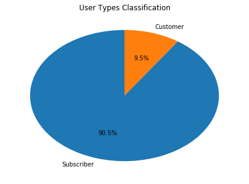

```python
user_types = ford_clean['user_type'].value_counts()
plt.figure(figsize=[7,5])
plt.pie(user_types , labels = user_types.index,startangle = 90, counterclock = True, autopct='%.1f%%', radius=1 );

plt.title('User Types Classification');
plt.show();
```

### Observation

> As we can see the pie plot shows that the Subscriber ( Member) user type is most popular than Customer (Casual)

### Visualization

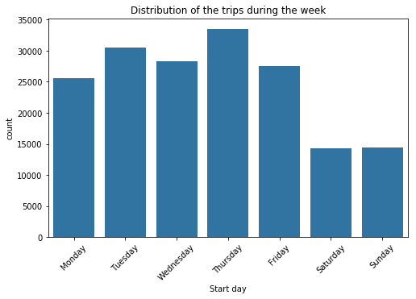

```python
plt.figure(figsize=[8, 5])
weekdays = ['Monday', 'Tuesday', 'Wednesday', 'Thursday', 'Friday', 'Saturday', 'Sunday']
base_color = sb.color_palette()[0]
sb.countplot(data = ford_clean, x = 'start_day', color = base_color, order = weekdays)
plt.xticks(rotation = 45)
plt.xlabel('Start day')
plt.title('Distribution of the trips during the week');
```

### Question:How does the classification of user gender is ?

### visulization

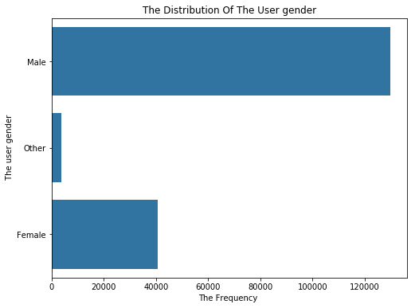

```python
# Create a figure with a specific size:
plt.figure(figsize = [8, 6])

# Use the base color to avoid any risk:
base_color = sb.color_palette()[0]

# Plot the distribution of the user type variable:
sb.countplot(data = ford_clean, y = 'member_gender', color = base_color);

# Put the labels:
plt.title("The Distribution Of The User gender")
plt.xlabel("The Frequency ")
plt.ylabel(" The user gender")

# Show the plot:
plt.show();
```

### Observation

> as we see in the graph most of the user are Male

### Question:How does the distrubution of user age ?

### Visulizaion

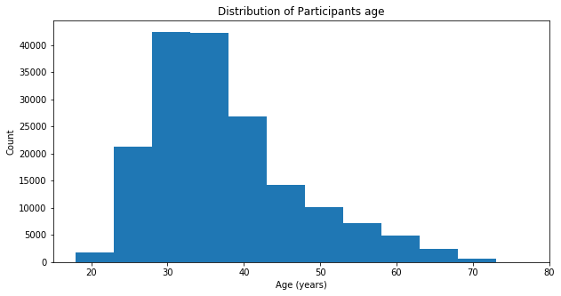

```python
bins_age = np.arange(18,141+5, 5 )
plt.figure(figsize=(10, 5))
plt.hist(data=ford_clean, x = 'age', bins=bins_age)
plt.xlim(15,80)

plt.title('Distribution of Participants age')
plt.xlabel('Age (years)')
plt.ylabel('Count')

plt.show()
```

### Observation

> as we see in the graph most of the age of users are between 23 and 38

### Question:How does the distrubution of trip duration?

### Visulizaion

```python
# to simplify the duration_sec, I'll convert it from seconds to minutes.
ford_clean.insert(loc=1, column='duration_min', value= ford_clean['duration_sec'] / 60)
```

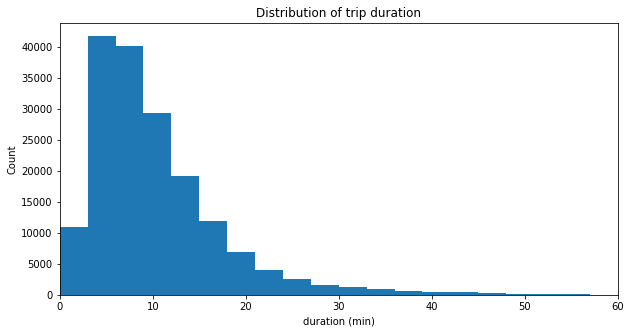

```python
bins= np.arange(0, 60, 3)
plt.figure(figsize=(10, 5))
plt.hist(data=ford_clean, x = 'duration_min', bins=bins)
plt.xlim(0, 60)
plt.title('Distribution of trip duration')
plt.xlabel('duration (min)')
plt.ylabel('Count')

plt.show()
```

### Observation

> The majority of the trip duration is is around 10 minutes then it begins to decrease. Trips that longer than 30 minutes are not frequent.

### Discuss the distribution(s) of your variable(s) of interest. Were there any unusual points? Did you need to perform any transformations?

> There were more trips on workdays (Monday to Friday) compared to weekends.

> Most of the members are men. Most of the members are between 23 to 38 years old.

> Most of the users are subscribers

> No, I didn't need to perform any transformations.

### Of the features you investigated, were there any unusual distributions? Did you perform any operations on the data to tidy, adjust, or change the form of the data? If so, why did you do this?

> The distribution of the member_agewe only interesed with people's age <70

> For the transformation i convert duration trip from sec to min in order to get a clear graph .

## Bivariate Exploration

### Qestion: weekday vs trip duration

### Visulisation

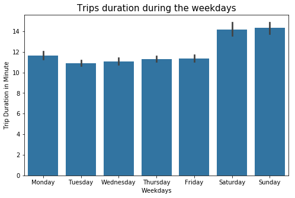

```python
plt.figure(figsize=[8, 5])
base_color = sb.color_palette()[0]
sb.barplot(data=ford_clean, x='start_day', y = 'duration_min', color=base_color,order=weekdays);
plt.xlabel('Weekdays');
plt.ylabel('Trip Duration in Minute')
plt.title('Trips duration during the weekdays',fontsize=15)
plt.grid(False);
```

### Observation

> The highest duration of the trips is on the weekend (Saturday and Sunday). On the working days, the duration of the trips is less than on the weekend and is between 10 to 12 minutes.

### Question : user type vs member gender?

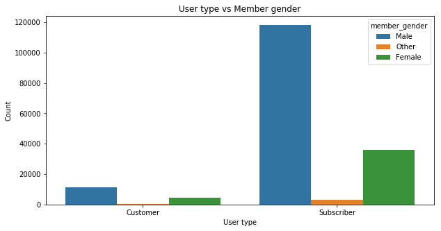

```python
plt.figure(figsize=[10, 5])
sb.countplot(data=ford_clean, x="user_type", hue="member_gender")
plt.xlabel('User type');
plt.ylabel('Count')
plt.title('User type vs Member gender')
plt.grid(False);
```

### Observation

> Most of the subscribers or customers are men

### Question User type and member gender vs trip duration

### Visulization

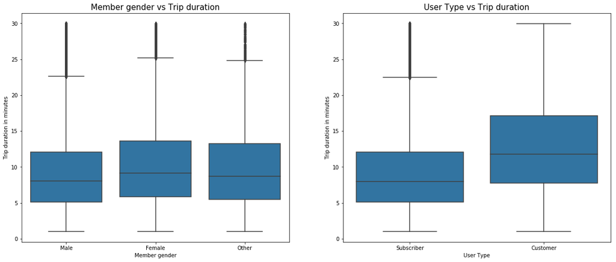

```python
plt.figure(figsize = [20, 8])
base_color = sb.color_palette()[0]

# left plot:
plt.subplot(1, 2, 1)
sb.boxplot(data=ford_clean.loc[ford_clean["duration_min"] < 30], x='member_gender', y='duration_min', color = base_color)
plt.xlabel('Member gender');
plt.ylabel('Trip duration in minutes');
plt.title('Member gender vs Trip duration',fontsize=15);
plt.grid(False);

# right plot:
plt.subplot(1, 2, 2)
sb.boxplot(data=ford_clean.loc[ford_clean["duration_min"] < 30], x='user_type', y='duration_min', color = base_color)
plt.xlabel('User Type');
plt.ylabel('Trip duration in minutes');
plt.title('User Type vs Trip duration',fontsize=15);
plt.grid(False);
```

### Observation

> The box plots tell us that the Customer bike trips are longer than Subscriber bike trips. We can see that the Customer median line is above the Subscriber median line. We can conclude from the left graph that females' trips are longer than men's trips.

> As seen in the previous graphs, most of the trips are less than 30 minutes, so it was necessary to limit the y-axis to include the trip duration shorter than 30 minutes, to get a clear graph.

### Question :what is the relationship between trip duration and age?

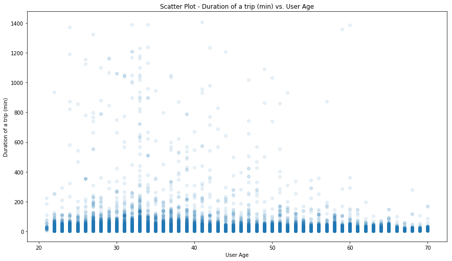

```python
# scatter plot of duration_min vs. age, with log transform on duration_min axis
plt.figure(figsize=[14.70, 8.27])
plt.scatter(data = ford_clean, x = 'age', y = 'duration_min', alpha = 1/10)
plt.title("Scatter Plot - Duration of a trip (min) vs. User Age")
plt.xlabel('User Age')
plt.ylabel('Duration of a trip (min)')
plt.show()
```

### Observation

> This plot suggests from the concavity that There is no relation between age and duration of the trip. Even though, the plot suggests that trip with duration > 100 min peaks at the age of 32 and decrease until it dispear before the age of 70.

### Talk about some of the relationships you observed in this part of the investigation. How did the feature(s) of interest vary with other features in the dataset?

> The bivariate analysis showed that the number of customers and subscibers was high among males than among females.

> On the weekend (Saturday and Sunday): the Trips' duration is longer than trips' duration during the working days. On the working days: the Trips' duration is shorter than on the weekend.

> Most of the users are subscribers, and most of them are men. The trips' duration for subscribers is shorter than the trips for customers. Women ride longer trips than men.

## Multivariate Exploration

> Create plots of three or more variables to investigate your data even further. Make sure that your investigations are justified, and follow from your work in the previous sections.

### Question :Relationship between age and trip duration by gender

### Visulization

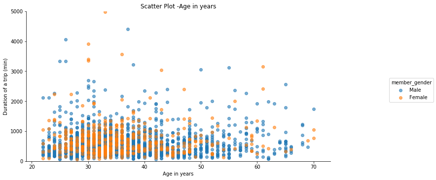

```python
#filtre
ford_gen =ford_clean[ford_clean['member_gender'].isin(['Male', 'Female'])]
#draw a sample of 2000 for clarity
sample_data=ford_gen.sample(n=2000, replace = False)
#scatter plot of age vs duration by gender
g = sb.FacetGrid(data = sample_data, hue = 'member_gender', size = 5)
g.map(plt.scatter, 'age', 'duration_sec', alpha=0.6)
g.add_legend()
g.set(ylim=(0,5000))
## Set Plot Dimensions - FIGURE LEVEL
g.fig.set_size_inches(14, 5)
#add xlabel, ylabel and title
plt.title("Scatter Plot -Age in years")
plt.xlabel('Age in years')
plt.ylabel('Duration of a trip (min)')
plt.show()
```

### Observation

> The scatter plot to investigate the relationship between age and duration in seconds by gender shows that there is an interaction between male and female ages but no interaction with trip duration.

### Question:Start day vs Trip duration in minutes vs Member gender

```python
### Visulization
```

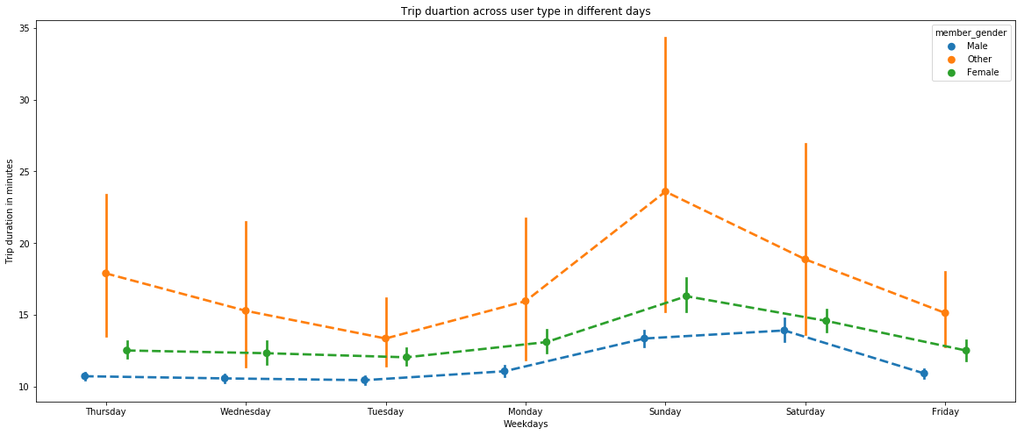

```python
fig = plt.figure(figsize = [20,8])
sb.pointplot(data = ford_clean, x = 'start_day', y = 'duration_min', hue = 'member_gender', dodge = 0.3, linestyles = "--")
plt.title('Trip duartion across user type in different days')
plt.ylabel('Trip duration in minutes')
plt.xlabel('Weekdays')
plt.show();
```

### Observation

Males and Females: The Trips duration are almost constant during the working days and increase during the weekend.

Males ride slightly longer trips on Saturday, but females ride slightly longer trips on Sunday.

Other: graph show unconstant trip duration across the weekday. They ride shorter trips on Tuesday and Friday, and slightly longer trips on Monday and Wednesday. They ride the longest trips are on Sunday followed by Saturday.

The previous chart confirms our findings that, in general, females ride longer trips than males, and trip duration for member gender other is the longest.

### Question :What is the Distribution of trip duartion across user type in different days?

### Visulization

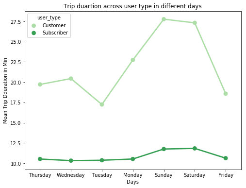

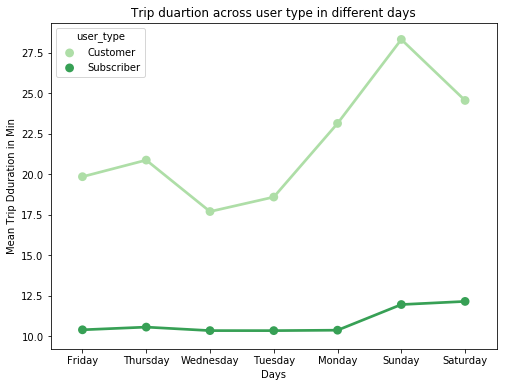

```python
fig = plt.figure(figsize = [8,6])
sb.pointplot(data = ford_clean, x = 'start_day', y = 'duration_min', hue = 'user_type', palette = 'Greens', ci=None)

plt.title('Trip duartion across user type in different days')
plt.ylabel('Mean Trip Dduration in Min')
plt.xlabel('Days')
plt.show();
fig = plt.figure(figsize = [8,6])
sb.pointplot(data = ford_clean, x = 'end_day', y = 'duration_min', hue = 'user_type', palette = 'Greens', ci=None)

plt.title('Trip duartion across user type in different days')
plt.ylabel('Mean Trip Dduration in Min')
plt.xlabel('Days')
plt.show();
```

### Question:Member gender vs user type vs the trip duration

### Visulization

```
Text(0.5,24,'User type')
```

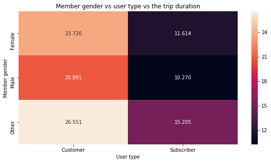

```python
avg_trip_duration = ford_clean.groupby(['member_gender', 'user_type']).mean()['duration_min']
avg_trip_duration = avg_trip_duration.reset_index()
avg_trip_duration = avg_trip_duration.pivot(index = 'member_gender', columns = 'user_type', values = 'duration_min' )
plt.figure(figsize = [10, 5])
sb.heatmap(avg_trip_duration, annot = True, fmt = '.3f')
plt.title('Member gender vs user type vs the trip duration')
plt.ylabel('Member gender')
plt.xlabel('User type')
```

### Observation

> The previous graph confirmed our last findings related to gender, user type, and trip duration.

> The trips' duration for both Male and female subscribers is almost the same.

> In general, the trips' duration is longer for user type 'customer' especially the women.

> The average trip duration for other is higher than those for women and men regardless of the user type.

### Visulization

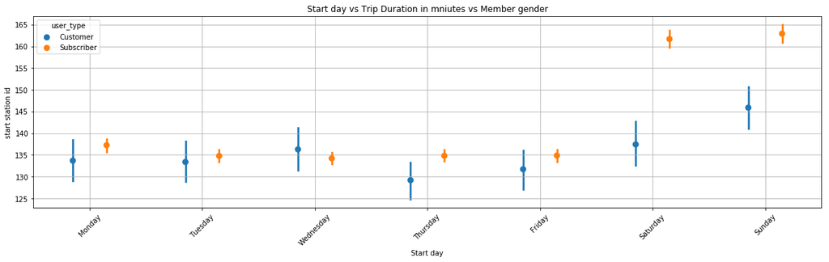

```python
plt.figure(figsize = [20, 5])
ax = sb.pointplot(data = ford_clean, x = 'start_day', y = 'start_station_id', hue = 'user_type',
                  dodge = 0.3, linestyles = "" ,order=weekdays)
plt.title('Start day vs Trip Duration in mniutes vs Member gender')
plt.ylabel('start station id')
plt.xlabel('Start day')
plt.xticks(rotation = 45)
#ax.set(ylim=(135, 140));
plt.grid(True);
```

### Observation

1- Subscribers: Monday >> start station id '137'

Tuesday >> start station id '134'

Wednesday >> start station id '133'

Thursday >> start station id '134'

Friday >> start station id '134'

Saturday >> start station id '162'

Sunday >> start station id '163'

2- Customers Monday >> start station id '134'

Tuesday >> start station id '133'

Wednesday >> start station id '136'

Thursday >> start station id '129'

Friday >> start station id '131'

Sunday >> start station id '144'

### Talk about some of the relationships you observed in this part of the investigation. Were there features that strengthened each other in terms of looking at your feature(s) of interest?

> the average trip duration for both Male and female subscribers is almost the same.

> The trip duration increases in the weekend.

> customers ride longer rides especially the women.

> the first plot, the customer has longer trips duration than subscriber .

### Were there any interesting or surprising interactions between features?

> I was interested and also surprised because I didn't expect to see the customer has longer trips than subscribers.

## Conclusions

> The number of males who participated in the Ford GoBike trips were more than females.

> Most of the participants in the Ford GoBike trips were subscribers and not customers.

> Subscribers took lesser time to complete the trip than customers.

> Male participants appear to complete the trip faster than females.

> There were more males than females both in the customer and subscriber category.

> Regardless of the user type, male participants took lesser time to complete the trip than females.